# Applied Information Analysis (Microeconometrics)

# Introduction

The aim of this subject is to provide economists sufficient knowledge of the most updated topics in microeconometrics so that they can choose the most appropriate estimators as well as exploit both the databases and economic models.

The program is designed to respond to the needs of researchers and practitioners when working with real data, where an important dimension in the unit of analysis is the individual. This requires the use of micro data and the use of advanced techniques in (micro) econometrics.

The practical content of this course has two objectives: on the one hand, the knowledge and management of the statistic-econometric software R; on the other hand, being able to solve practical cases that require the use of the various estimators explained in the theoretical part of the program.

Each session is split into two parts: a theoretical and an empirical part.

Outline :

- Topic 1: Linear models and cross-sectional data
- Topic 2: Limited Dependent Variable models: Binary Outcome models
- Topic 3: Panel Models and policy evaluation

Tentative calendar:

- Jan. 11, 18: Topic 1
- Jan. 25, Feb. 1: Topic 2 + Checkpoint
- Feb. 14, 15: Topic 3
- Feb. 29: Topic 3 + Exam Simulation

Pre-requirements:

- Knowledge of probability theory notions (random variables, probability/density function, cumulative probability/density function)
- Notions of inferential statistics (Estimator, Confidence Interval, Hypothesis Testing)
- Basic knowledge of R

# Topic 1: Linear models and Cross-Sectional Data

In this section, we will deal with **cross-sectional** data, that is a sample of observations coming from individuals, firms, countries, cities, states, or a variety of any units, observed at a given point in time.

In later sections, we will deal with **pooled cross sections** and **panel** data. An example of the former type of data is when we pool together two or more cross sectional datasets. A panel or longitudinal data set consists of a set of repeated observations for each cross-sectional member in the data set.

An important assumption throughout this course is that we will deal with a **random sample**, that is we assume no bias in the selection of observations. For example, if we are to study the wage of individuals, we need to randomly select $N$ individuals at random from the population. If, for example, there is some (or more) reason(s) for that observations are not drawn at random (e.g., imagine that rich individuals do not want to answer to a survey), the sample is said to be biased and we need to adopt different inferential techniques to account for that bias, albeit not always feasible.

### 1. Definition of Simple Linear Regression Model

Much of applied econometric analysis begins with the following premise: y and x are two variables, representing some population, and we are interested in “explaining y in terms of x,” or in “studying how y varies with changes in x.”

**Example 1**: Labor economists and policy makers have long been interested in the “return to education.” Somewhat informally, the question is posed as follows: If a person is chosen from the population and given another year of education, by how much will his or her wage increase?

The econometrics way to address these questions is to assume some functional form that explains how the link between y and x is modeled. The simplest model we could assume is a linear relationship between variables, i.e., a linear regression model. More formally:

$$\tag{1.1}
y = \beta_0 + \beta_1 \cdot x + u$$

The outcome variable $y$ is a linear combination of $x$ (the covariate) and parameters $\beta$. The component $u$ is an erratic component accounting for all factors affecting $y$ other than $x$.

Why is it called linear? Because $y$ is a linear function of the parameters $\beta$. And why should we care about the functional form? Because it has important consequences on the conclusions we can get about the link between variables.

Let’s have a look at the following equation, following Eq. 1.1:

$$\tag{1.2}
\Delta y = \beta_1 \cdot \Delta x,~ if ~ \Delta u = 0$$

Thus, the change in $y$ is simply $\beta_1$ multiplied by the change in $x$. This means that $\beta_1$ is the slope parameter in the relationship between $y$ and $x$, holding the other factors in $u$ fixed; it is of primary interest in applied economics.

The intercept parameter $\beta_0$ , sometimes called the constant term, also has its uses, although it is rarely central to an analysis.

The linearity of 1.2 implies that a one-unit change in x has the same effect on y, regardless of the initial value of x. This is unrealistic for many economic applications. For example, in the wage-education example, we might want to allow for increasing returns: the next year of education has a larger effect on wages than did the previous year. We will see how to allow for such possibilities later on in this course.

### 2. OLS Parameter estimation

The most-common approach used to estimate $\beta$ parameters is called Ordinary Least Squares (OLS). It aims at minimizing the distance between actual and model-predicted values of $y$.

In particular, we aim at minimizing the sum of squared residuals defined as:

$$min_{\beta_0, \beta_1} \Sigma_{i=1}^N (y_i - \beta_0 - \beta_1x_i)^2$$
By minimizing the equation above, the First order conditions (that is, putting the first derivative = 0) :

$$\begin{cases}
\frac{\partial \Sigma_{i=1}^N (y_i - \beta_0 - \beta_1x_i)^2}{\partial \beta_0} = 0 \\
\frac{\partial \Sigma_{i=1}^N (y_i - \beta_0 - \beta_1x_i)^2}{\partial \beta_1} = 0 \\
\end{cases}$$
which is :
$$\begin{cases}
-2 \Sigma_{i=1}^N (y_i - \beta_0 - \beta_1x_i) = 0 ~ , ~ (eq ~ 1) \\
-2 \Sigma_{i=1}^N x_i (y_i - \beta_0 - \beta_1x_i) = 0 ~, ~ (eq ~ 2)\\
\end{cases}$$

From solving eq 1 in the system, we knwo that

$$-2 ~\Sigma y_i- \Sigma \beta_0 - \Sigma \beta_1 x_i = 0 \\$$

and by dividing both sides by $n$ and multiplying by -2 :

$$\frac{\Sigma y_i}{n} - \frac{\Sigma \beta_0}{n} - \frac{\Sigma \beta_1 x_i}{n} = 0 \\$$
which is equivalent to :

$$\tag{eq. 3}
\bar y - \beta_0 - \beta_1 \bar x = 0 \rightarrow \beta_0 = \bar y - \beta_1 \bar x$$

Thus, knowing this, we can substitute $\beta_0$ in the equation eq 2 above:

$$\Sigma_{i=1}^N x_i (y_i - \color{red}{(\bar{y} - \beta_1 \bar{x})} - \beta_1x_i) = 0$$
hence, by decomposing the factors:

$$\tag{eq. 4}
\Sigma_{i=1}^N x_i (y_i - \bar{y}) = \beta_1 \Sigma_{i=1}^N x_i(x_i - \bar{x})$$
thence:

$$\tag{eq. 5}
\beta_1 = \frac{\Sigma_{i=1}^N x_i (y_i - \bar{y})}{\Sigma_{i=1}^N x_i(x_i - \bar{x})}$$

This equation 5 will give us the value of $\beta_1$. However, we can rewrite eq. 4 in a more compact way, by knowing that :

$$\Sigma_{i=1}^N (x_i - \bar x)\cdot(x_i - \bar x) = \Sigma_{i=1}^N x_i\cdot(x_i - \bar x)$$
because for the properties of mean values (the sum of deviations from the mean is null):

$$\bar x \Sigma_{i=1}^N (x_i - \bar x) = 0$$

Hence, eq. 4 becomes:

$$\beta_1 = \frac{\Sigma_{i=1}^N(x_i - \bar{x})(y_i - \bar{y})}{\Sigma_{i=1}^N (x_i - \bar{x})^2}$$

TO RECAP : From eq.s 3 and 4, we obtain the estimator for $\beta_1$ and $\beta_0$:

$$\begin{cases}
\beta_1 = \frac{\Sigma_{i=1}^N(x_i - \bar{x})(y_i - \bar{y})}{\Sigma_{i=1}^N (x_i - \bar{x})^2} \\
\beta_0 = \bar y - \beta_1 \bar x \\
\end{cases}$$

By checking the second order conditions, it is easily verified that b indeed corresponds to a minimum (do it as exercise).

By meeting first and second order conditions, we have derived the best linear approximation of $y$ ! The adjective ‘best’ refers to the fact that the sum of squared differences (approximation errors) is minimal.

### 3. From Algebra to Inference

Deriving OLS parameters as in the section above required only algebrical skills. However, economists are mostly interested in drawing conclusions from sample regarding the whole population. To do so, we need to treat our variables $y,x,u$ as random variables. Before proceding, make sure you know what a random variable is and refresh the concept of first and second moment of a random variable.

#### Population and sample Regression Function

Assuming that we have the whole population at hand, we can establish the following relation seen before:

$$\begin{equation}
\tag{Population Regression Function}
y = \beta_0 + \beta_1 x + u
\end{equation}$$

In this formulation, we assume to know the exact distribution of all variables.

However, in most cases, we only dispose of a sample of the population ${x_i, y_i}$. Hence, we are subject to measurement error and need to treat our model components as random variables.

In particular, given the different framework, we indicate the relationship estimated using the sample at hand as:

$$\begin{equation}
\tag{Sample Regression Function}
y = \hat{\beta_0} + \hat{\beta_1} x + \hat{u}
\end{equation}$$

Notice that, given that betas parameters depend on the sampling procedure (they are a function of the sample), these are also random variables themselves! Which implies that they have their own distribution, as we change the sample.

The rule which says how a given sample is translated into an approximate value for beta is referred to as an estimator. The result for a given sample is called an estimate. The estimator is a vector of random variables, because the sample may change. The estimate is a vector of numbers.

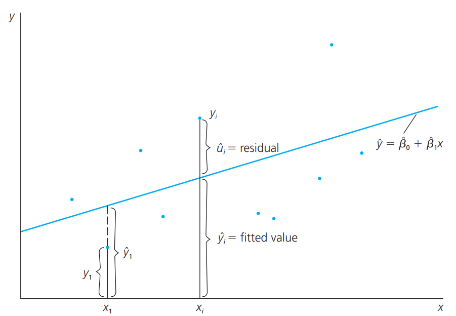

Figure 1.

### 4. Goodness of fit

Here we will learn how to understand whether our estimated model is a good fit of the data. Three main indicators:

$$\tag{Total Squared Sums}
SST_y = \Sigma_{i=1}^N(y_i - \bar{y})^2$$

$$\tag{Explained Squared Sums}
SSE_y = \Sigma_{i=1}^N(\hat{y_i} - \bar{y})^2$$

$$\tag{Residual Squared Sums}
SSR_y = \Sigma_{i=1}^N(\hat{u_i})^2$$
where SST = SSE + SSR

An index of goodness of fit is $R^2$:

$$R^2 = SSE/SST = 1 - SSR/SST$$

$R^2$ explains how well $x$ explains of the dependent variable $y$. A higher level of this index indicates a higher model fit.

That being said, low levels of R are quite common in social sciences (actually, beware of very high levels).

### 5. Example 1 - Case-study: CEOs salary determinants

This is a case-study from Woolridge’s book. The main question is: what are the determinants of CEOs salary? The database includes individual, cross-sectional data from several CEOs. For each CEO, we have several information regarding the company.

Type ‘help(ceosal2)’ to get a full description of the dataset

```r
library(wooldridge)

ceosal2
```

|  | salary | age | college | grad | comten | ceoten | sales | profits | mktval | lsalary | lsales | lmktval | comtensq | ceotensq | profmarg |
| --- | --- | --- | --- | --- | --- | --- | --- | --- | --- | --- | --- | --- | --- | --- | --- |
| 1 | 1161 | 49 | 1 | 1 | 9 | 2 | 6200 | 966 | 23200 | 7.057037 | 8.732305 | 10.051908 | 81 | 4 | 15.5806456 |
| 2 | 600 | 43 | 1 | 1 | 10 | 10 | 283 | 48 | 1100 | 6.396930 | 5.645447 | 7.003066 | 100 | 100 | 16.9611301 |
| 3 | 379 | 51 | 1 | 1 | 9 | 3 | 169 | 40 | 1100 | 5.937536 | 5.129899 | 7.003066 | 81 | 9 | 23.6686382 |
| 4 | 651 | 55 | 1 | 0 | 22 | 22 | 1100 | -54 | 1000 | 6.478509 | 7.003066 | 6.907755 | 484 | 484 | -4.9090910 |
| 5 | 497 | 44 | 1 | 1 | 8 | 6 | 351 | 28 | 387 | 6.208590 | 5.860786 | 5.958425 | 64 | 36 | 7.9772081 |
| 6 | 1067 | 64 | 1 | 1 | 7 | 7 | 19000 | 614 | 3900 | 6.972606 | 9.852194 | 8.268732 | 49 | 49 | 3.2315791 |
| 7 | 945 | 59 | 1 | 0 | 35 | 10 | 536 | 24 | 623 | 6.851185 | 6.284134 | 6.434546 | 1225 | 100 | 4.4776120 |
| 8 | 1261 | 63 | 1 | 1 | 32 | 8 | 4800 | 191 | 2100 | 7.139660 | 8.476371 | 7.649693 | 1024 | 64 | 3.9791667 |
| 9 | 503 | 47 | 1 | 1 | 4 | 4 | 610 | 7 | 454 | 6.220590 | 6.413459 | 6.118097 | 16 | 16 | 1.1475409 |
| 10 | 1094 | 64 | 1 | 1 | 39 | 5 | 2900 | 230 | 3900 | 6.997596 | 7.972466 | 8.268732 | 1521 | 25 | 7.9310346 |

[output cut: 167 more lines]

```r
NA
```

Let’s run our first regression:

```r
model1 <- lm(salary~profits, data=ceosal2)
stargazer(model1, type = 'html', star.cutoffs = c(0.05, 0.01, 0.001),
          notes = c("$*p<0.05$", "$**p<0.01$", "$***p<0.001$"), notes.append=FALSE)
```

|  | *Dependent variable:* |
| --- | --- |
|  | salary |
| profits | 0.572*** |
|  | (0.101) |
| Constant | 746.924*** |
|  | (45.798) |
| Observations | 177 |
| R<sup>2</sup> | 0.155 |
| Adjusted R<sup>2</sup> | 0.150 |
| Residual Std. Error | 541.619 (df = 175) |
| F Statistic | 32.144*** (df = 1; 175) |
| *Note:* | *p<0.05 |
|  | **p<0.01 |
|  | ***p<0.001 |

```r
est_plot <- plot_model(model1, type = "est") + ggplot2::theme_bw()
```

Argument ‘df_method’ is deprecated. Please use ‘ci_method’ instead.

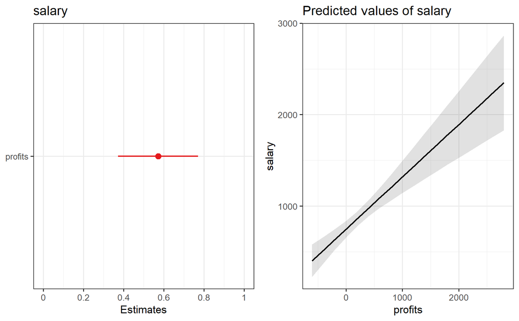

```r
pred_plot <- plot_model(model1, type = "pred", term="profits") + ggplot2::theme_bw()
ggpubr::ggarrange(est_plot, pred_plot, nrow = 1)
```

Let’s have a look at our $\hat u$, that is the residuals of our model (the difference between observed $y$ and predicted $\hat y$ values):

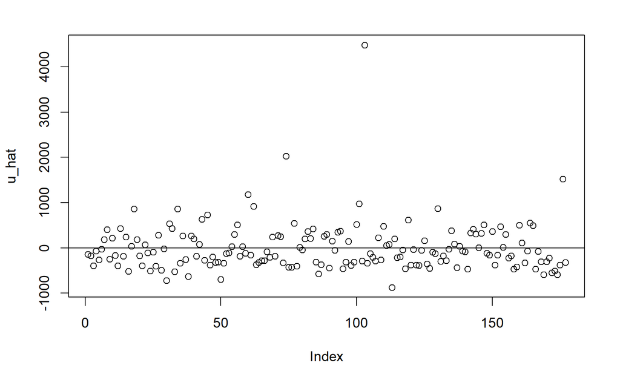

```r
u_hat <- resid(model1)
plot(u_hat); abline(h=0) # run altogether
```

```r
print(paste("The mean of residuals is: ", round(mean(u_hat),0))) # mean of residuals
```

```
[1] "The mean of residuals is:  0"
```

The average of residuals is practically zero, which is a good sign as per our model goodness of fit.

One way to measure the dispersion of the model random error is to use the residual standard error, which is a way to measure the standard deviation of the residuals:

$$RSE = \sqrt{SS_u/df_u}$$

```r
print(paste("The residuals SE is: ", round(sqrt(sum(u_hat^2)/(model1$df.residual)),2))) # mean of residuals
```

```
[1] "The residuals SE is:  541.62"
```

**Notes**: remember the difference between *correlation* and *causation*! Despite we are tempted to say that making more profits in a firm causes a higher level of CEOs salaries, what we estimated is just an association between variables.

### 6. Theoretical Assumptions of linear models (Gauss-Markov)

Since our parameter estimators ($\hat \beta$) are a combination of random variables $X$ and $Y$, they are themselves random variables. This is essential to understand!!! By changing the sample, you will have different estimates of the OLS estimators, yet, we can make conclusions about their distribution characteristics (i.e., imagine to draw 100 samples and run 100 regressions: you will end up with a distribution of OLS parameters from which you can calculate the empirical mean, standard deviation and such).

To draw conclusions regarding the population we need to make some assumptions. These assumption help preventing systematic biases in the estimation of beta parameters, hence drawing misleading conclusions about our model.

The standard set of assumption is the so called Gauss-Markow assumptions.

$$E[u]=0 ~ \tag{A1}$$
$$E[u|X]=E[u] \tag{A2}$$
$$Var(u|X) = Var(u) = \sigma^2 < \inf \tag{A3}$$

$$cov(u_i, u_j)=0 \tag{A4}$$

Assumption (A1) says that the expected value of the error term is zero, which means that, on average, the regression line should be correct.

Assumption (A2) states that the errors and the covariates are independent. Note: If you do not recall what a conditional expectation is, check here https://en.wikipedia.org/wiki/Conditional_expectation.

Assumption (A3) states that all error terms have the same variance, which is referred to as homoskedasticity, while assumption (A4) imposes zero correlation between different error terms. This excludes any form of autocorrelation.

Taken together, (A1), (A3) and (A4) imply that the error terms are uncorrelated drawings from a distribution with expectation zero and constant variance $\sigma^2$

Under these assumptions, we can say that the $E(y|x)=\beta_0 + \beta_1 x$, meaning that our regression model tells us how the average value of y changes with x; it does not say that y equals b0 + b1x for all units in the population.

[figure not shown]

Figure. 2

### 7. Properties of OLS estimator under Gauss-Markov assumptions

Here we study a set of assumptions that need to be respected in order to have ‘good estimates’. What good estimates refers to are two main properties: being a correct-on-average estimator, and making minimal errors.

Let us assume a simple linear model

$$y = \beta_0 + \beta_1 \cdot x + u$$

#### Unbiased estimator

You will see here that A2 is an important assumption as it makes the OLS estimator unbiased.

$$E[\hat{\beta}]=\beta$$
Proof:

$$\hat{\beta} = \frac{\Sigma_{i=1}^N(x_i - \bar{x})y_i}{\Sigma_{i=1}^N (x_i - \bar{x})^2}$$

$$= \frac{\Sigma_{i=1}^N(x_i - \bar{x})(\beta_0 + \beta_1 x_i + u_i)}{\Sigma_{i=1}^N (x_i - \bar{x})^2}$$

Considering the numerator:

$$= \beta_0 \Sigma_{i=1}^N(x_i - \bar{x}) + \beta_1 \Sigma_{i=1}^Nx_i(x_i - \bar{x}) + \Sigma_{i=1}^N u_i (x_i - \bar{x}) \\$$

knowing that :

$$\Sigma_{i=1}^N(x_i - \bar{x}) = 0 ;$$

$$\Sigma_{i=1}^Nx_i(x_i - \bar{x}) = \Sigma_{i=1}^N(x_i - \bar{x})^2;$$

hence:

$$\hat{\beta} = \beta_1 + \frac{\Sigma_{i=1}^N(x_i - \bar{x})u_i}{\Sigma_{i=1}^N(x_i - \bar{x})^2} = \frac{Cov(x,u)}{Var(x)}$$

Hence, if $E[u_i]=0$ (A2), $E[\hat{\beta_1}]=\beta_1$

#### Best linear unbiased estimator

The variance of $\hat{\beta}$ is the minimal among all possible linear unbiased estimators. This is proved in the Gauss-Markov Theorem (Proof not given.)

$$Var(\hat{\beta_1}) = \frac{\sigma^2}{SST_x}$$

#### Normal distribution of $\hat \beta$

Under the further assumption that
$$\tag{A5} u_i \sim N(0,\sigma^2)$$
,

the estimator $\hat \beta$ follows a normal distribution:

$$\hat{\beta}\sim N(\beta, Var(\hat\beta))$$

### 8. Asymptotic properties

The GM assumptions work under small samples (whatever small sample means). We have also seen that under assumption A5, the estimator of beta is normally distributed under the assumption that errors are also normally distributed.

However, from a practical and theoretical point of view, knowing the behavior of our betas becomes more challenging when any of such assumptions is relaxed.

In this case, we can study some asymptotical properties, that is, properties that arise when the sample size is very large (to the limit, infinite).

The main point here being that, despite some assumptions may not be empirically met, we can achieve and derive some useful (and statistically reassuring) properties of OLS estimators by increasing the sample size.

#### Consistency

Define N as the sample size, $\beta_N$ is the OLS parameter estimated starting from such a sample.

Under the assumption A1-4, especially A2 (no relation between $X$ and $u$), OLS beta is said consistent estimator, formally:

$$plim_{N \to + \infty} ~ \hat{\beta_n} = \beta$$
or

$$lim_{N \to \infty} Prob(abs(\hat{\beta} - \beta)>\delta) = 0$$
for any $\delta>0$

Consistency is a so-called large sample property and, loosely speaking, says that if we obtain more and more observations, the probability that our estimator is some positive number away from the true value β becomes smaller and smaller.

#### Asymptotic Normality

The exact normality of the OLS estimators hinges crucially on the normality of the distribution of the error, u, in the population. Under assumptions A1-5, we assume an explicit distribution of $\hat \beta$, which allows us to perform inference (hypothesis tests, and confidence intervals using t and F distributions – see references, Wooldridge chapter 4; Verbeek chapter 2.5).

However, even relaxing this assumption, we can derive the asymptotical distribution of betas. Under the GM conditions (most importantly homoskedasticity, A3), it can be shown that (proof not given):

$$\sqrt N (\hat \beta - \beta) \sim^a N(0, \sigma^2/SSR)$$

### 9. Example 2 - Monte-Carlo Simulation to study OLS properties

Now let’s do a simulation (Monte Carlo) to show the properties of unbiadness and consistency.

Let’s use the CEO dataset to understand what a MC simulation is. We then will use simulated data to show that by estimating OLS parameters on several samples, we can draw an empirical distribution of $\hat \beta$ from which we can study the expected value (the mean, $E(\hat \beta)$).

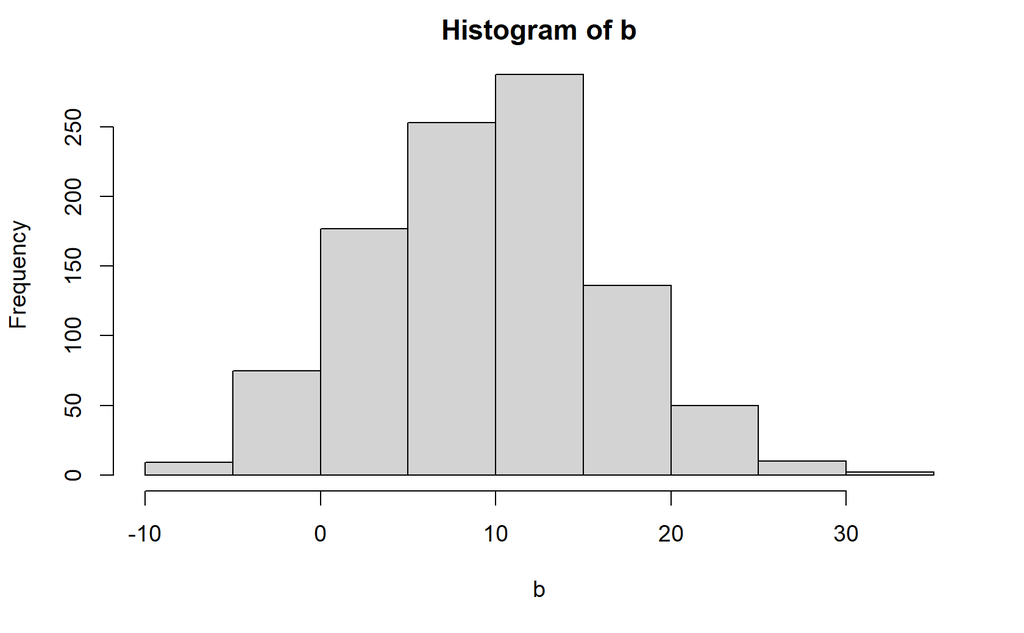

```r
set.seed(123)
b=NA
for (j in 1:1000){
  df <- ceosal1[sample(nrow(ceosal2), size = 100),]
  tempmodel <- lm(salary~roe, data=df)
  b[j] <- coef(tempmodel)["roe"]
}
hist(b)
```

```r
mean(b)
```

```
[1] 9.52459
```

You have just done your first sampling algorithm simulation!

Let us now create a fake dataset from which we know the real $\beta$, something we do not really know for the CEO dataset.

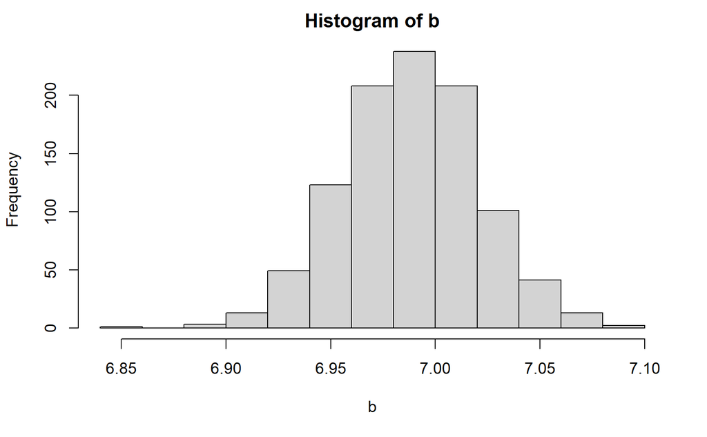

```r
# create the dataset that represents the population
x <- rnorm(1000, mean=20, sd=3)
u <- rnorm(1000, 0, 1)
y= 3 + 7*x + u
## note: beta0 = 3, beta1 = 7; we are assigning exogenously these values to see whether our OLS estimators are good consistent

dataset <- data.frame(y=y, x=x)

# run now a MC simulation
set.seed(123)
b=NA
for (j in 1:1000){
  df <- dataset[sample(nrow(dataset), size = 100),]
  tempmodel <- lm(y~x, data=df)
  b[j] <- coef(tempmodel)["x"]
}
hist(b)
```

```r
mean(b)
```

```
[1] 6.988547
```

Why and when to use MC method?

- One main useful reason is power analyses (we will deal with this later, but for the time being, think of it as a method to ensure that your estimators have enough statistical power to detect an effect, for example a treatment effect).
- surely you can use MC methods when dealing with very large datasets and you want to run your model on several random samples

### 10. Multiple regression

Insofar, we have considered a linear model with only 1 covariate, or regressor. Yet, models can become richer by including more covariates.

Everything said before still holds (some notation and formulas slightly change, see chapter 3 of Wooldridge book), however, it is important to gauge the interpretation of coeffients of a multiple regression model.

Let’s assume the following estimated OLS model:

$$\hat y = \hat \beta_0 + \hat \beta_1 x_1 + \hat \beta_2 x_2 + ... + \hat \beta_k x_k$$

the general estimate $\hat \beta_j$ with $j \in \{1, 2, ..., k\}$ is considered a **partial effect**, i.e., the effect associated to the variable $x_j$, holding constant (in latin, ceteris paribus) all the other variables. More formally:

$$\partial \hat y / \partial x_j = \hat \beta_j$$

#### Case-study: CEOs salary (continued)

Let us add additional covariates in the model, for example the variable ‘age’. Does a CEO salary increase with their age?

```r
model2 <- lm(salary~profits + age, data = ceosal2)

stargazer(model1, model2, type = 'html', star.cutoffs = c(0.05, 0.01, 0.001),
          notes = c("$*p<0.05$", "$**p<0.01$", "$***p<0.001$"), notes.append=FALSE)
```

|  | *Dependent variable:* |  |
| --- | --- | --- |
|  | salary |  |
|  | (1) | (2) |
| profits | 0.572*** | 0.560*** |
|  | (0.101) | (0.102) |
| age |  | 4.962 |
|  |  | (4.879) |
| Constant | 746.924*** | 469.386 |
|  | (45.798) | (276.732) |
| Observations | 177 | 177 |
| R<sup>2</sup> | 0.155 | 0.160 |
| Adjusted R<sup>2</sup> | 0.150 | 0.151 |
| Residual Std. Error | 541.619 (df = 175) | 541.566 (df = 174) |
| F Statistic | 32.144*** (df = 1; 175) | 16.592*** (df = 2; 174) |
| *Note:* | *p<0.05 |  |
|  | **p<0.01 |  |
|  | ***p<0.001 |  |

```r
plot_model(model2, type = "est") + ggplot2::theme_bw()
```

Argument ‘df_method’ is deprecated. Please use ‘ci_method’ instead.

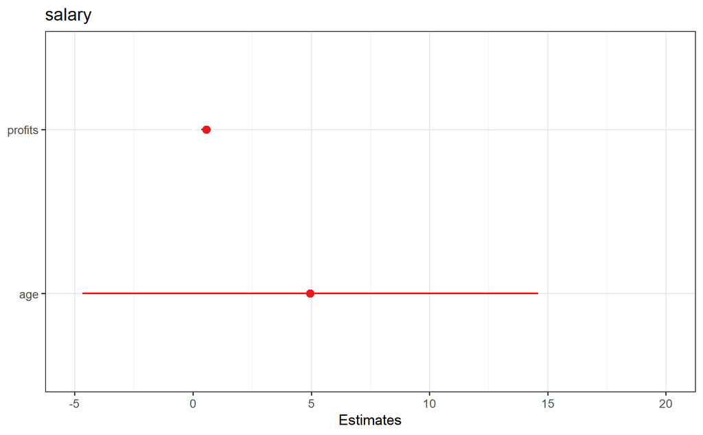

### 11. Multiple regression with qualitative independent variables

In many cases, regression models include also qualitative variables, such as gender, or race, and such.

We will start with the simplest qualitative variable, a dummy variable, or zero-one variable. These variables can only take values 0 or 1 to indicate whether the observation meets a certain condition (e.g., being male). When introduced in a model, their interpretation is easy to understand and can account for intra-group differences:

```r
data("wage1")
model_qualitative <- lm(wage~educ + female, data = wage1)

stargazer(model_qualitative, type = 'html', star.cutoffs = c(0.05, 0.01, 0.001),
          notes = c("$*p<0.05$", "$**p<0.01$", "$***p<0.001$"), notes.append=FALSE)
```

|  | *Dependent variable:* |
| --- | --- |
|  | wage |
| educ | 0.506*** |
|  | (0.050) |
| female | -2.273*** |
|  | (0.279) |
| Constant | 0.623 |
|  | (0.673) |
| Observations | 526 |
| R<sup>2</sup> | 0.259 |
| Adjusted R<sup>2</sup> | 0.256 |
| Residual Std. Error | 3.186 (df = 523) |
| F Statistic | 91.315*** (df = 2; 523) |
| *Note:* | *p<0.05 |
|  | **p<0.01 |
|  | ***p<0.001 |

```r
plot_model(model_qualitative, type = "est") + ggplot2::theme_bw()
```

Argument ‘df_method’ is deprecated. Please use ‘ci_method’ instead.

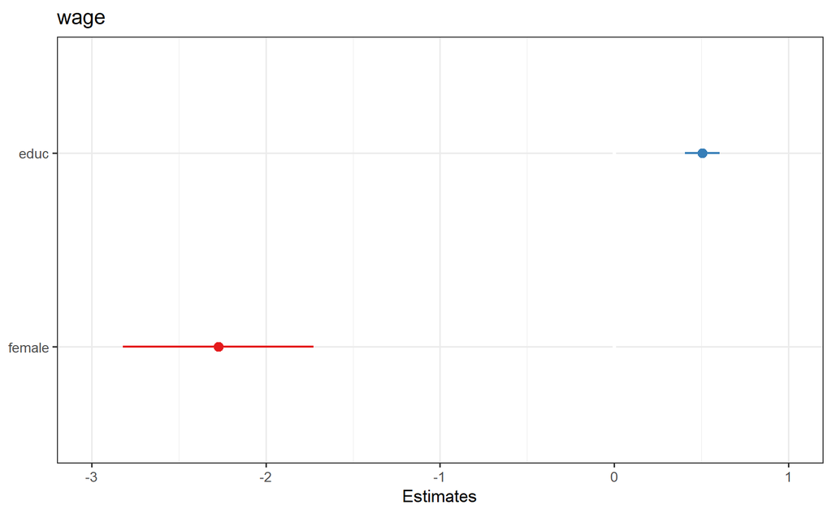

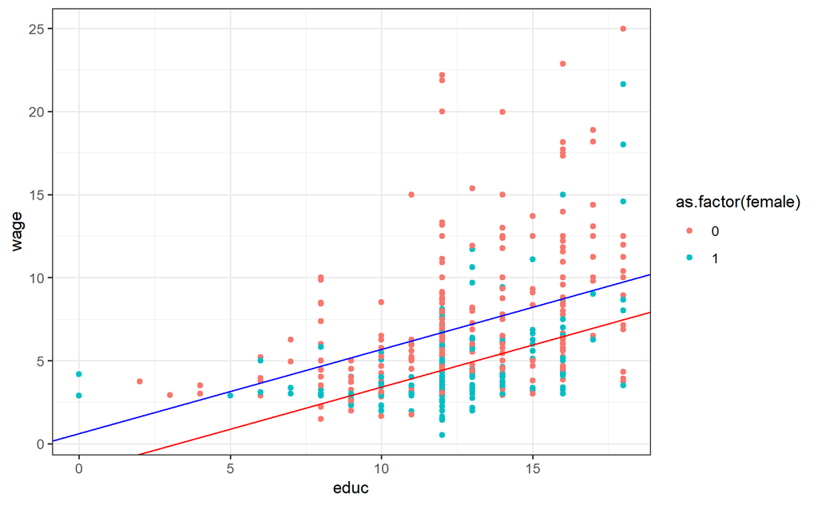

```r
# plot models for each group separately
## retrieve coefficients
betas <- coef(model_qualitative)
yhat_female <- betas[1] + betas[3] + betas[2]*wage1$educ
yhat_male <- betas[1] + betas[2]*wage1$educ

ggplot(data=wage1, aes(x=educ, y=wage, color=as.factor(female))) + geom_point() + geom_abline(intercept = betas[1], slope = betas[2], color="blue") + geom_abline(intercept = betas[1] + betas[3], slope = betas[2], color="red") + theme_bw()
```

The coefficient onfemale is interesting because it measures the average difference in hourly wage between a man and a woman who have the same levels of educ

$$E(wage|female=1, educ) - E(wage|female=0, educ)$$

**Notes**: Notice that when using dummy variables to distinguish among N qualitative categories (e.g., for gender, male and female), we should include N-1 variables as the Nth category is accounted by the constant term of the model. If you include N dummies, you will have multicollinearity issues. An equivalent way in R is to include categorical variables as *factor* variable in a regression model.

For example, if we want to estimate the difference in wage between married and not married people, based on their gender, we would end up with 4 categories. How to model this in a regression? A basic way would be to use two dummies:

```r
wage1$married_male = ifelse(wage1$female==0 & wage1$married == 1, 1, 0)
wage1$married_female = ifelse(wage1$female==1 & wage1$married == 1, 1, 0)
wage1$single_female = ifelse(wage1$female==1 & wage1$married == 0, 1, 0)

model_multiple_cat_1 <- lm(wage ~educ + married_male + married_female + single_female, data=wage1)

## alternative

wage1$marital_gender = wage1$married_gender <- dplyr::case_when(
                                                      wage1$female == 0 & wage1$married == 0 ~ "Single - Male",
                                                      wage1$female == 0 & wage1$married == 1 ~ "Married - Male",
                                                      wage1$female == 1 & wage1$married == 0 ~ "Single - Female",
                                                      TRUE ~ "Married - Female"
)


model_multiple_cat_2 <- lm(wage ~ educ + married_gender, data=wage1)

stargazer(model_multiple_cat_1, model_multiple_cat_2, type = 'html', star.cutoffs = c(0.05, 0.01, 0.001),
          notes = c("$*p<0.05$", "$**p<0.01$", "$***p<0.001$"), notes.append=FALSE)
```

|  | *Dependent variable:* |  |
| --- | --- | --- |
|  | wage |  |
|  | (1) | (2) |
| educ | 0.494*** | 0.494*** |
|  | (0.049) | (0.049) |
| married_male | 2.641*** |  |
|  | (0.399) |  |
| married_female | -0.557 |  |
|  | (0.425) |  |
| single_female | -0.369 |  |
|  | (0.433) |  |
| married_genderMarried - Male |  | 3.198*** |
|  |  | (0.349) |
| married_genderSingle - Female |  | 0.188 |
|  |  | (0.387) |
| married_genderSingle - Male |  | 0.557 |
|  |  | (0.425) |
| Constant | -1.024 | -1.581* |
|  | (0.693) | (0.661) |
| Observations | 526 | 526 |
| R<sup>2</sup> | 0.317 | 0.317 |
| Adjusted R<sup>2</sup> | 0.311 | 0.311 |
| Residual Std. Error (df = 521) | 3.065 | 3.065 |
| F Statistic (df = 4; 521) | 60.318*** | 60.318*** |
| *Note:* | *p<0.05 |  |
|  | **p<0.01 |  |
|  | ***p<0.001 |  |

Notice that values are different as the reference category between regression models is different. In model (1) the baseline category is “Single - Male”, while in (2) is “Married - Female”.

Hence, we would need to do some math calculations (for example, -1.024 = -1.581 + 0.557)

A way to change reference categories in R is to use the function *relevel()*.

### 12. Interaction terms

Sometimes, it is natural for the partial effect, elasticity, or semi-elasticity of the dependent variable with respect to an explanatory variable to depend on the magnitude of yet another explanatory variable. For example, in the model:

$$y = \beta_0 + \beta_1 x_1 + \beta_2 x_2 + \beta_3 x_1 \cdot x_2$$
the partial effect of $x_1$, is then $\frac{\partial y}{\partial x_1}= \beta_1 + \beta_3 \cdot x_2$ and depends on the value of the variable $x_2$. While $\beta_1$ is the sheer effect of $x_1$ onto $y$ when $x_2=0$, this is not very useful when it comes to interpret our model.

If $x_2$ is a continuous variable, **how to evaluate then the marginal effect of $x_1$?** There is no unique answer, but the general recommendation is to study the marginal effect at a meaningful value of $x_2$, for example at its mean value ($\bar x_2$).

The marginal effect hence becomes: $\frac{\partial y}{\partial x_{1}}_{|x_2=\bar x_2}= \beta_1 + \beta_3 \cdot \bar x_2$

#### Interaction with a binary variable

It is particularly useful (and common) to use interaction terms when one of the interacted variable is a dummy one (binary variable that takes values either 0 or 1). Examples are all models that aim to investigate the relationship between two variables depending on groups (e.g., gender, treatment or control, etc.)

```r
data("wage2")
#help(wage2)

# model with no interaction term
model_interaction_1 <- lm(wage~educ + black, data = wage2)
model_interaction_2 <- lm(wage~educ*black, data = wage2)

stargazer(model_interaction_1, model_interaction_2, type = 'html', star.cutoffs = c(0.05, 0.01, 0.001),
          notes = c("$*p<0.05$", "$**p<0.01$", "$***p<0.001$"), notes.append=FALSE)
```

|  | *Dependent variable:* |  |
| --- | --- | --- |
|  | wage |  |
|  | (1) | (2) |
| educ | 55.020*** | 58.377*** |
|  | (5.714) | (5.956) |
| black | -189.995*** | 320.620 |
|  | (37.507) | (262.778) |
| educ:black |  | -40.723* |
|  |  | (20.743) |
| Constant | 241.297** | 195.571* |
|  | (78.936) | (82.185) |
| Observations | 935 | 935 |
| R<sup>2</sup> | 0.131 | 0.135 |
| Adjusted R<sup>2</sup> | 0.129 | 0.132 |
| Residual Std. Error | 377.366 (df = 932) | 376.789 (df = 931) |
| F Statistic | 70.204*** (df = 2; 932) | 48.231*** (df = 3; 931) |
| *Note:* | *p<0.05 |  |
|  | **p<0.01 |  |
|  | ***p<0.001 |  |

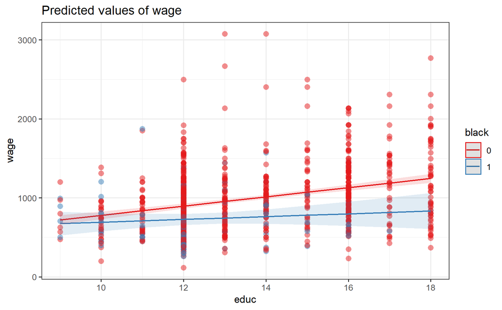

```r
plot_model(model_interaction_2, type = "int", show.data = TRUE) + theme_bw()
```

#### Interaction with a continuous variable

Interacting two continuous variables makes interpretation of the interaction more complicated visualize.

A good way to visualize the interaction effect is to pick some values of one of the variables. Let us estimate a model in which education and age are interacted:

```r
model_interaction_3 <- lm(wage~educ*age, data = wage2)

summary(model_interaction_3)
```

```
Call:
lm(formula = wage ~ educ * age, data = wage2)

Residuals:
    Min      1Q  Median      3Q     Max
-851.31 -249.09  -30.51  200.41 2226.02

Coefficients:
            Estimate Std. Error t value Pr(>|t|)
(Intercept)  1639.99     864.16   1.898   0.0580 .
educ         -103.97      64.17  -1.620   0.1055
age           -44.13      25.58  -1.726   0.0848 .
educ:age        4.89       1.90   2.574   0.0102 *
---
Signif. codes:  0 ‘***’ 0.001 ‘**’ 0.01 ‘*’ 0.05 ‘.’ 0.1 ‘ ’ 1

Residual standard error: 375.8 on 931 degrees of freedom
Multiple R-squared:  0.139, Adjusted R-squared:  0.1362
F-statistic: 50.08 on 3 and 931 DF,  p-value: < 2.2e-16
```

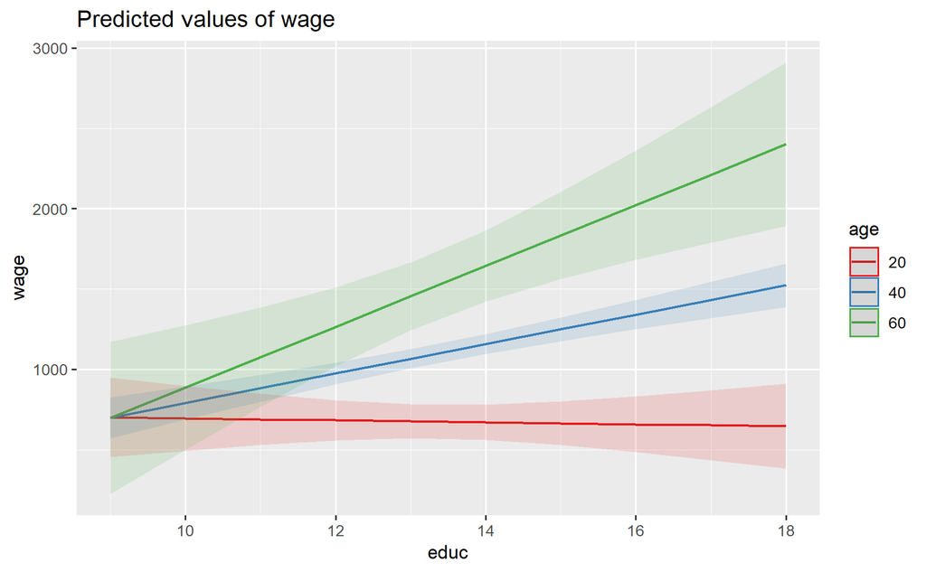

```r
plot_model(model_interaction_3, type = "pred", terms = c("educ", "age [20,40,60]"))
```

### 13. Further issues when estimating OLS

#### Heteroskedasticity

Assumption A3 assumed that the variance of $u$ is independent of $X$ variables, hence, it is constant irrespective of what value our regressors take.

**What happens, however, when this assumption is violated?** Our OLS estimators are still unbiased and consistent, yet the estimated variance $Var(\hat \beta)$ is not BLUE (Best Linear Unbiased Estimator) anymore, and it becomes biased. This would produce biased and incorrect t-tests, and confidence intervals. All in all, our inferences about $\hat \beta$ are incorrect.

**When do we encounter this kind of issue?** For example, when we analyze consumption choices depending on income levels: it is likely to assume that richer people can afford both cheap and more costly goods, while poorer people can only afford the former. Hence, we could observe something similar to the following simulated data:

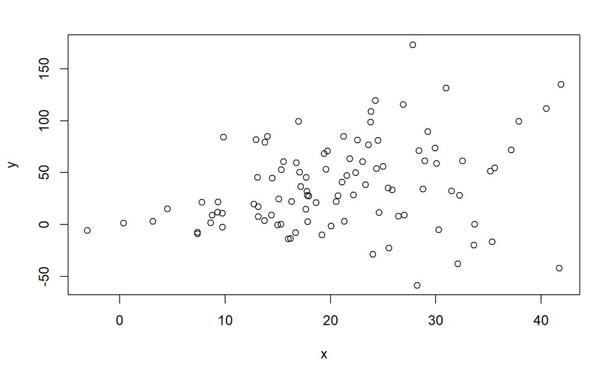

```r
# create the dataset that represents the population
set.seed(123)
n <- 1:100
x <- rnorm(100, mean=20, sd=10)
u <- rnorm(100, 0, 2)
y= 1 + 2*x + u*x

plot(x = x, y = y)
```

If we run a standard regression model:

```r
# Non-robust ols
ols <- lm(y~x, data=data.frame(x,y))
summary(ols)
```

```
Call:
lm(formula = y ~ x, data = data.frame(x, y))

Residuals:
     Min       1Q   Median       3Q      Max
-106.165  -23.841   -4.742   24.177  127.025

Coefficients:
            Estimate Std. Error t value Pr(>|t|)
(Intercept)  10.4865    10.3120   1.017  0.31169
x             1.2897     0.4524   2.850  0.00532 **
---
Signif. codes:  0 ‘***’ 0.001 ‘**’ 0.01 ‘*’ 0.05 ‘.’ 0.1 ‘ ’ 1

Residual standard error: 41.09 on 98 degrees of freedom
Multiple R-squared:  0.07656,   Adjusted R-squared:  0.06714
F-statistic: 8.125 on 1 and 98 DF,  p-value: 0.005322
```

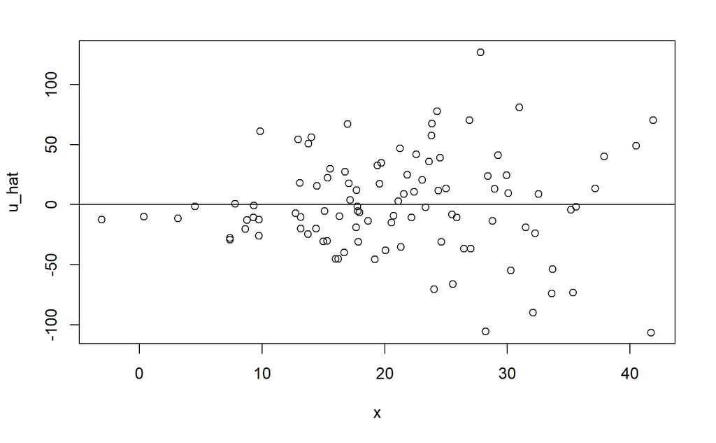

```r
u_hat <- resid(ols)

plot(x, u_hat); abline(h=0) # run altogether
```

How to test for heteroskedasticity? We can use the Breusch-Pagan (BP) test, where the null hypothesis is that there is no heteroskedasticity.

The steps for the BP test:

1. Estimate the OLS model, and obtain $\hat u$
2. Regress the residuals on all the model covariates: $\hat u = \delta_0 + \delta_1 x_1 + \delta_2 x_2 + ... + \delta_k x_k$
3. Keep the R-squared from the point before
4. Compute the statistics $LM = n \cdot R^2_{\hat u^2}$, which, under the null, follows a $\chi^2$ distribution with $k$ degrees of freedom

It may sound complicated, but fortunately, there is ready-made function for this:

```r
library(lmtest) # for functions bptest and coeftest
library(sandwich) # for computing variance-covariance in coeftest
# test for heteroskedasticity
bptest(ols)
```

```
    studentized Breusch-Pagan test

data:  ols
BP = 14.381, df = 1, p-value = 0.0001493
```

```r
# run a model with heteroskedastic-robust errors
coeftest(ols, vcov=vcovHC(ols, "HC0")) # explore the other possible adjustments (HC1)
```

```
t test of coefficients:

            Estimate Std. Error t value Pr(>|t|)
(Intercept) 10.48654    9.00673  1.1643  0.24713
x            1.28968    0.50331  2.5624  0.01192 *
---
Signif. codes:  0 ‘***’ 0.001 ‘**’ 0.01 ‘*’ 0.05 ‘.’ 0.1 ‘ ’ 1
```

Look at the estimates between the two models: they are the same. What now changes are the standard errors and the related inferences.

#### Omitted variables bias

Omitting a relevant variable that explains a phenomenon can cause a bias in our estimates. The mathematical reason is given below:

Assuming the **actual** population regression model is :

$$y = \beta_0 + \beta_1 x_1 + \beta_2 x_2 + u$$

yet, we estimate the model:

$$y = \beta_0 + \beta_1 x_1 + e$$

where the erratic component $e = \beta_2 x_2 + u$.

If $Cov(x_1, x_2) \neq 0$, the explained and erratic components of the model are correlated, which violates one of the fundamental assumptions of the Gauss-Markov theorem (see A2).

Notice that omitting one important variable can possibly compromise the estimates of all parameters in the model, not only those correlated with the omitted variable.

#### Specifying alternative functional forms

In many empirical applications in economics, it is not uncommon to apply some transformation to some of the regressors or dependent variables. Some common transformations are:

- scaling: subtracting the average of a variable and dividing by its standard deviation
- using natural logarithms of a variable

##### Scaling

Let us begin with the former transformation, scaling. We will continue the previous example on CEOs salary. The goal is to compare estimates using original and scaled variables.

```r
model3 <- lm(salary~scale(profits) + scale(age), data = ceosal2)

stargazer(model2, model3, type = 'html', star.cutoffs = c(0.05, 0.01, 0.001),
          notes = c("$*p<0.05$", "$**p<0.01$", "$***p<0.001$"), notes.append=FALSE)
```

|  | *Dependent variable:* |  |
| --- | --- | --- |
|  | salary |  |
|  | (1) | (2) |
| profits | 0.560*** |  |
|  | (0.102) |  |
| age | 4.962 |  |
|  | (4.879) |  |
| scale(profits) |  | 226.673*** |
|  |  | (41.093) |
| scale(age) |  | 41.789 |
|  |  | (41.093) |
| Constant | 469.386 | 865.864*** |
|  | (276.732) | (40.707) |
| Observations | 177 | 177 |
| R<sup>2</sup> | 0.160 | 0.160 |
| Adjusted R<sup>2</sup> | 0.151 | 0.151 |
| Residual Std. Error (df = 174) | 541.566 | 541.566 |
| F Statistic (df = 2; 174) | 16.592*** | 16.592*** |
| *Note:* | *p<0.05 |  |
|  | **p<0.01 |  |
|  | ***p<0.001 |  |

```r
plot_model(model3, type = "est") + theme_bw()
```

Argument ‘df_method’ is deprecated. Please use ‘ci_method’ instead.

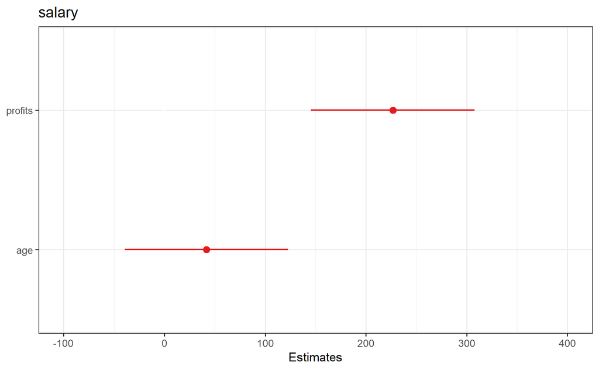

Notice a couple of things:

- regressors that were significant are still so
- Goodness of fit has not changed
- the constant term has changed since it depends on the other estimates

How to interpret the estimated parameters: now the estiamted parameters are often called standardized or scaled betas. Given the standardized nature of the regressors, we can interpret each beta as the change we would observe in in $y$ associated with a 1 standard deviation change in any given $x$.

When to use scaled variables? Scaling regressors can be useful when the dependent and the independent variables have very different scales, or their natural scale is hard to interpret. In our example, salary is expressed in 1000$ whiel profits are in millions. The relationship could become easier to interpret after scaling. Another example is that of when using scores (e.g., SAT scores, or grades).

##### Logarithmization

THe second useful transformation concerns applying logarithms. Historically, economists like logs for their properties (see Appendix). For example, the difference of logs approximate well percentage changes. However, the main reason why we use logs in regression model are two: one is because it makes OLS assumption easier to meet; the second is because it facilitates parameters interpretation.

To understand the first point, let’s have a look at the distribution of salaries from the CEO data, both in the natural and the logarithmic scale:

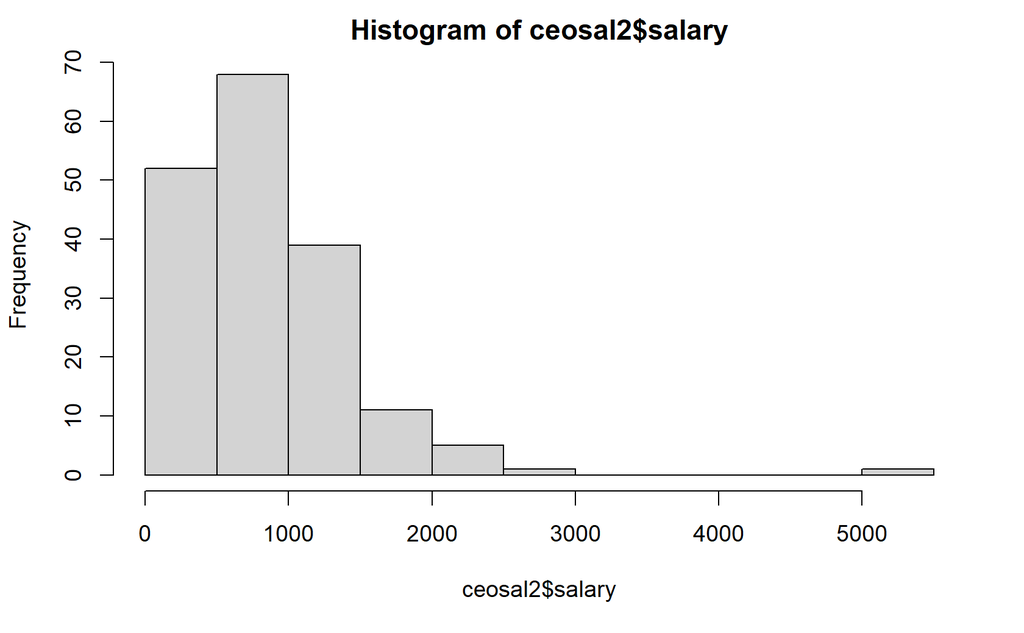

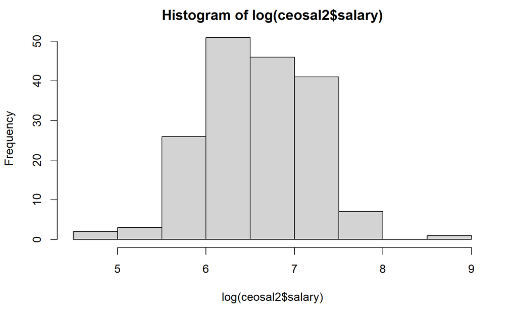

```r
hist(ceosal2$salary); hist(log(ceosal2$salary))
```

```r
model4 <- lm(log(salary)~profits + age, data = ceosal2)

stargazer(model2, model4, type = 'html', star.cutoffs = c(0.05, 0.01, 0.001),
          notes = c("$*p<0.05$", "$**p<0.01$", "$***p<0.001$"), notes.append=FALSE)
```

|  | *Dependent variable:* |  |
| --- | --- | --- |
|  | salary | log(salary) |
|  | (1) | (2) |
| profits | 0.560*** | 0.001*** |
|  | (0.102) | (0.0001) |
| age | 4.962 | 0.003 |
|  | (4.879) | (0.005) |
| Constant | 469.386 | 6.276*** |
|  | (276.732) | (0.286) |
| Observations | 177 | 177 |
| R<sup>2</sup> | 0.160 | 0.159 |
| Adjusted R<sup>2</sup> | 0.151 | 0.150 |
| Residual Std. Error (df = 174) | 541.566 | 0.559 |
| F Statistic (df = 2; 174) | 16.592*** | 16.500*** |
| *Note:* | *p<0.05 |  |
|  | **p<0.01 |  |
|  | ***p<0.001 |  |

Compute the residuals from both models

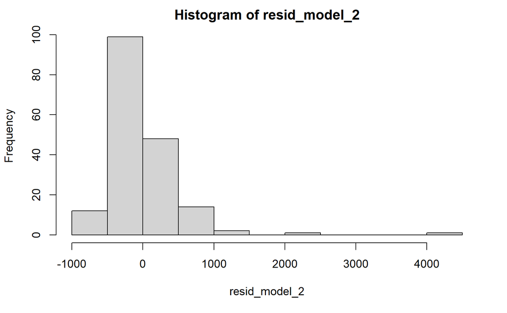

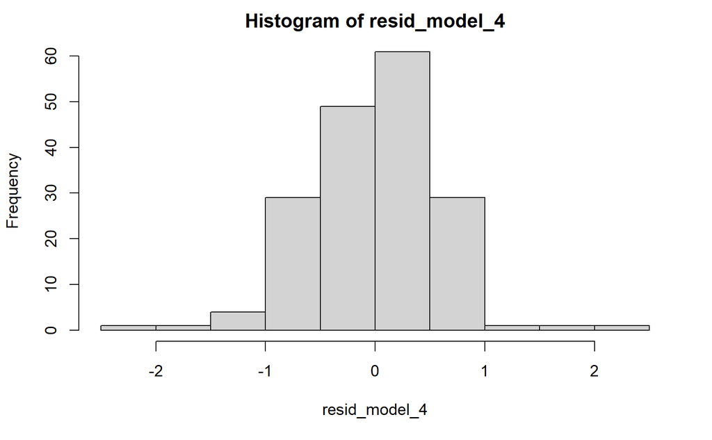

```r
resid_model_2 <- resid(model2)
resid_model_4 <- resid(model4)

hist(resid_model_2); hist(resid_model_4)
```

When logarithmizing the dependent variable, the residuals look more normal. This can be an advantage in terms of model performance.

However, whenever transforming a log-transformation to any of the variables in the model, its interpretation change as well.

Let us consider:

$$log(y) = \beta_0 + \beta_1 x + u$$

In this case, $\beta_1$ represents the percentage change in $y$ assocaited with a unit change in $x$. This model is referred to as log-linear model.

In a similar fashion, we can build linear-log models, or log-log models.

#### Regressor selection and model comparison

When studying a phenomenon, it is hard to know which is the real data generating process. To build a good model, it requires, first, a good knowledge of the phenomenon at hand, and good data.

When we have good knowledge of the phenomenon, and yet have several model specifications in mind, we can rely upon some indicators that will tell us which variables to include, and whether they are relevant in the model.

Ideally, in the effort to avoid the omitted variable bias, one wants to estimate the most comprehensive model. However, it is not always good to include many variables: we won’t have biased estimates when including an irrelevant variable, yet we will produce a biased variance of the estimated parameters as

$$Var(\beta_j)= \frac{\sigma^2}{SST_j (1-R^2_j)}$$

where $\sigma^2$ is the variance of the erratic component, $SST_j = \Sigma_i(x_{ij} - \bar x_j)^2$ and $R^2_j$ is the R-squared from regressing $x_j$ on all the other variables in the model.

Hence, the more variables we include in the model, the higher are the chances that the variables are somewhat correlated, i.e., the $R^2_j$ can be high. We are falling in the multicollinearity trap.

**Then what is the answer to build a good model?**. There is no right answer. The first need is to plan ahead your model specification, even before looking at the data. The specification of the model has to be as much parsimonious as possible, and should include only variables that are theoretically relevant, or have a reason to be included.

There exists a way to compare **nested** models, that is models in which one includes a subset of variables of another. In this case, one can look at some indicators. For example, the $R^2$ or adjusted-$R^2$ can be indicators. TO understand whether the inclusion of one or more variables significantly increases the predicatbility of the model, one can use the F-test on some parameter restrictions. Let’s have a look at the previous example: does the inclusion of age improve model’s performance? We can use the anova() function in r

```r
unrestricted_model <- lm(salary~profits + age, data = ceosal2)
restricted_model <- lm(salary~profits, data = ceosal2)

stargazer(unrestricted_model, restricted_model, type = 'html', star.cutoffs = c(0.05, 0.01, 0.001),
          notes = c("$*p<0.05$", "$**p<0.01$", "$***p<0.001$"), notes.append=FALSE)
```

|  | *Dependent variable:* |  |
| --- | --- | --- |
|  | salary |  |
|  | (1) | (2) |
| profits | 0.560*** | 0.572*** |
|  | (0.102) | (0.101) |
| age | 4.962 |  |
|  | (4.879) |  |
| Constant | 469.386 | 746.924*** |
|  | (276.732) | (45.798) |
| Observations | 177 | 177 |
| R<sup>2</sup> | 0.160 | 0.155 |
| Adjusted R<sup>2</sup> | 0.151 | 0.150 |
| Residual Std. Error | 541.566 (df = 174) | 541.619 (df = 175) |
| F Statistic | 16.592*** (df = 2; 174) | 32.144*** (df = 1; 175) |
| *Note:* | *p<0.05 |  |
|  | **p<0.01 |  |
|  | ***p<0.001 |  |

After looking at the indicators $R^2$ and adj-$R^2$ it seems that the inclusion of the variable age has not improved much the model goodness-of-fit. The F-test displayed is not the one we need (the one displayed is only about testing a linear restriction on all parameters). We need to perform a F-test only on the inclusion and exclusion of age.

The F-test is of the following kind:

$$F = \frac{(SSR_r - SSR_u)/q}{SSR_u/(n-k-1)}=\frac{(R^2_u - R^2_r)/q}{(1-R^2_u)/(n-k-1)}$$

where $n$ is the number of observations, $k$ the number of variables in the unrestricted model, and $q$ the number of variables not included in the restricted model.

The test answers the question: does the reduction in SSE provide enough evidence that the full model describes the population more accurately than the restricted model?

The hypotheses can be translated in terms of coefficients:

$$H_0 : \beta_{q+1}=\beta_{q+2}=\beta_{q+3}=...=\beta_{k}=0$$

Now, we can test the hypothesis that excluding *age* significantly reduces the goodness-of-fit of the model:

```r
anova(unrestricted_model, restricted_model)
```

```
Analysis of Variance Table

Model 1: salary ~ profits + age
Model 2: salary ~ profits
  Res.Df      RSS Df Sum of Sq      F Pr(>F)
1    174 51033058
2    175 51336367 -1   -303309 1.0342 0.3106
```

or the library car

```r
# alternative
car::linearHypothesis(unrestricted_model, c("age=0"), test="F")
```

```
Linear hypothesis test

Hypothesis:
age = 0

Model 1: restricted model
Model 2: salary ~ profits + age

  Res.Df      RSS Df Sum of Sq      F Pr(>F)
1    175 51336367
2    174 51033058  1    303309 1.0342 0.3106
```

In both cases, the null hypothesis is not rejected, hence including the predictor *age* has not improved the model predictability.

### Appendix

#### OLS Assumption Set

It is worth noting that some books use a different, yet similar, set of assumptions to derive OLS properties, both for small sample and asymptotics.

For example, Wooldridge, for multiple linear regressions, consistency is assumed if:

1. Linearity in coefficients: the model has to be linear
2. Random sampling of $X$ and $Y$, i.e., $\{(x_i, y_i)\}$; this means that there is no serial correlation between random draws of the population
3. No perfect collinearity: a variable is not the exact linear combination of others in the model
4. Zero conditional mean of errors, that is:

$$E(U|X_k)=0$$

if we add homoskedasticity assumption, OLS is also the best linear unbiased estimator (minimal variance).

#### Taylor’s approximation for logarithm and percentage change

Here we provide the mathematical proof that a difference in logarithm approximates a percentage change using the first order Taylor’s approximation.

For any $x=1$

$$log(1+x) = log(1) + dy/dx/1! (x-1) + dy/dx/2! * (x-1)^2 ...$$

if we stop at first order:

$log(1+x) = 0 + 1/1 * (x-1)=x-1$

hence

$log(x_1) - log(x_2) = log(\frac{x_1}{x_2}) = \frac{x_1}{x_2} - 1 = \frac{x_1-x_2}{x_2}$

### Exercises

#### OLS Simple regression

The data set BWGHT contains data on births to women in the United States. Two variables of interest are the dependent variable, infant birth weight in ounces ($bwght$), and an explanatory variable, average number of cigarettes the mother smoked per day during pregnancy ($cigs$). The following simple regression was estimated using data on n = 1,388 births:

1. What is the predicted birth weight when cigs = 0? What about when cigs = 20 (one pack per day)? Comment on the difference.
2. Does this simple regression necessarily capture a causal relationship between the child’s birth weight and the mother’s smoking habits? Explain.
3. To predict a birth weight of 125 ounces, what would cigs have to be? Comment.
4. The proportion of women in the sample who do not smoke while pregnant is about .85. Does this help reconcile your finding from part (iii)

#### OLS Simple regression 2

Use the data in WAGE2 to estimate a simple regression explaining monthly salary (wage) in terms of IQ score (IQ).

1. Find the average salary and average IQ in the sample. What is the sample standard deviation of IQ? (IQ scores are standardized so that the average in the population is 100 with a standard deviation equal to 15.)
2. Estimate a simple regression model where a one-point increase in IQ changes wage by a constant dollar amount. Use this model to find the predicted increase in wage for an increase in IQ of 15 points. Does IQ explain most of the variation in wage?
3. Now, estimate a model where each one-point increase in IQ has the same percentage effect on wage. If IQ increases by 15 points, what is the approximate percentage increase in predicted wage?

#### OLS Multiple regression Estimates

1. The following model can be used to study whether campaign expenditures affect election outcomes:

$$voteA = b0 + b1 \cdot log(expendA) + b2 \cdot log(expendB) + b3 \cdot prtystrA + u$$

where voteA is the percentage of the vote received by Candidate A, expendA and expendB are campaign expenditures by Candidates A and B, and prtystrA is a measure of party strength for Candidate A (the percentage of the most recent presidential vote that went to A’s party).

1. What is the interpretation of b1?
2. In terms of the parameters, state the null hypothesis that a 1% increase in A’s expenditures is offset by a 1% increase in B’s expenditures.
3. Estimate the given model using the data in VOTE1 and report the results in usual form. Do A’s expenditures affect the outcome? What about B’s expenditures? Can you use these results to test the hypothesis in 2. ?
4. Estimate a model that directly gives the t statistic for testing the hypothesis in q. 2. What do you conclude? (Use a two-sided alternative.)

#### MC Simulation

1. Create a random dataset with 5000 obervations including a dep. var (y) and a covariate (x). The y is linearly modeled by x, with real parameters beta0 = 0.5, beta1 = 7 (this step is called defining the data generator process)
2. Run a MC simulation with random samples of 100. Note the results and compare them with the following point.
3. Now run a MC simulation to show the unbiasedness of OLS estimators. Use a random sample of 5000.
4. Plot the results

Now, reply these questions:

Question 1: How does the empirical distribution of beta look like?

Question 2: What happens to the distribution as we increase the sample in the MC simulation

# Topic 2: Binary outcome models

In many cases, we are interested in modeling dependent variables that are limited in the possible number of outcomes they can take. Most of economic variables are restricted, yet they do not always need special treatment. If a strictly positive variable takes on many different values, a special econometric model is rarely necessary. When $y$ is discrete and takes on a small number of values, it makes no sense to treat it as an approximately continuous variable.

A limited dependent variable (LDV) is broadly defined as a dependent variable whose range of values is substantively restricted and it can be:

- A binary variable, often called a dummy variable, which can take only two values, e.g., 0 or 1. Examples are buying decisions about a product, whether it rains today or not, taking part of a program or not, etc.
- A truncated variable, such as income, consumption, percentages, etc.

That being said, it is not always the case to say that a linear model is not a good way to model these variables. One should understand whether the nature of the variable (and its distribution) may lead to biased estimates when using linear models.

We will start by the case of binary dependent variable (notice: in the previous sections, we have seen the case of binary independent variables, keep in mind the difference)

### Intro to binary variable models

Let us assume that we want to model a variable describing a phenomenon which can only take two values, e.g., 0 or 1, conditional upon an event, e.g., buying a product or not. Formally,

- $y = 0$, if i does not buy the product
- $y = 1$, if i buys the product

Ideally, one can consider the outcome of $y$ as the product of a *latent* (unobserved) dependent variable $y^*$. In the example of consumption, it can be the *utility function* of an individual such that:

- if $y^*>0$, then $y=1$
- if $y^*\leq 0$, then $y=0$

Since we cannot observe $y^*$, we aim to model the variable $y$ which is observable. Our interest is to model it as a probability response function:

$$P(y=1|x_1, x_2, ..., x_k)=F(\beta_0 + \beta_1 x_1 + ... + \beta_k x_k)$$

where $F$ is any function of the regressors and parameters. The question however is: which function to choose?

### Linear probability model

A simple approach is to keep $F$ linear in the parameters $\beta$ as we have seen previously in any OLS model.

$$P(y=1|x_1, x_2, ..., x_k)=E(y|x)=\beta_0 + \beta_1 x_1 + ... + \beta_k x_k$$

When $F$ is assumed to be linear, and the assumptions we have seen in the OLS section still hold, we obtain the *linear probability model* (LPM).

**How to interpret $\beta$s in a LPM**? We cannot apply the same reasoning as before. Parameters $\beta$ do not represent the change in $y$ ($\Delta y$) corresponding to a unitary change in $x$ ($\Delta x$=1) as it can only take two values! We have to interpret everything in terms of the probability for $y=1$:

$$\Delta P(y=1|\textbf{x})= \beta \Delta x$$

Let us make an example.

```r
data("mroz")
library(dplyr)

lpm <- lm(inlf ~ nwifeinc + educ + exper + expersq + age + kidslt6 + kidsge6, data=mroz %>% mutate(expersq=exper*exper))

summary(lpm)
```

```
Call:
lm(formula = inlf ~ nwifeinc + educ + exper + expersq + age +
    kidslt6 + kidsge6, data = mroz %>% mutate(expersq = exper *
    exper))

Residuals:
     Min       1Q   Median       3Q      Max
-0.93432 -0.37526  0.08833  0.34404  0.99417

Coefficients:
              Estimate Std. Error t value Pr(>|t|)
(Intercept)  0.5855192  0.1541780   3.798 0.000158 ***
nwifeinc    -0.0034052  0.0014485  -2.351 0.018991 *
educ         0.0379953  0.0073760   5.151 3.32e-07 ***
exper        0.0394924  0.0056727   6.962 7.38e-12 ***
expersq     -0.0005963  0.0001848  -3.227 0.001306 **
age         -0.0160908  0.0024847  -6.476 1.71e-10 ***
kidslt6     -0.2618105  0.0335058  -7.814 1.89e-14 ***
kidsge6      0.0130122  0.0131960   0.986 0.324415
---
Signif. codes:  0 ‘***’ 0.001 ‘**’ 0.01 ‘*’ 0.05 ‘.’ 0.1 ‘ ’ 1

Residual standard error: 0.4271 on 745 degrees of freedom
Multiple R-squared:  0.2642,    Adjusted R-squared:  0.2573
F-statistic: 38.22 on 7 and 745 DF,  p-value: < 2.2e-16
```

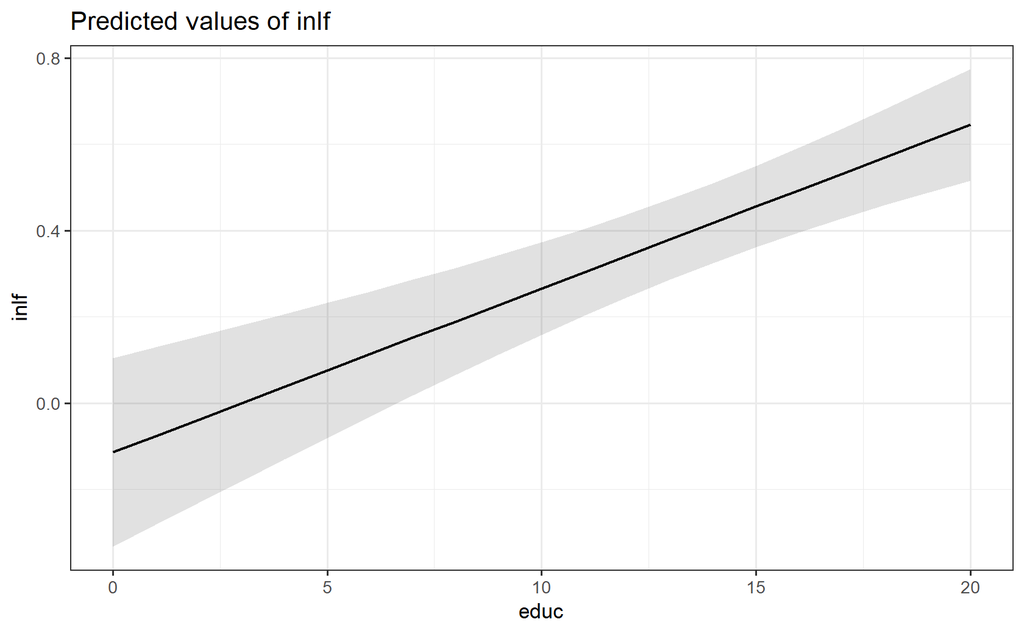

```r
predicted_vals <- ggeffects::ggpredict(lpm, terms = c("educ [0:20]", "exper [5]", "nwifeinc [50]"))
plot(predicted_vals) + ggplot2::theme_bw()
```

How to check if our model is performing well? We can use the percent of correctly predicted

```r
predicted_lpm <- predict(lpm)
dataframe_lpm <- data.frame(y_hat=predicted_lpm, y=mroz$inlf) %>%
  mutate(correct=ifelse((y_hat>0.5 & y ==1)|(y_hat<=0.5 & y ==0), "Yes", "No"))

table(dataframe_lpm$correct)
```

```
 No Yes
200 553
```

### Limitations: towards a more accurate model specification

From the previous analysis, three main limitations arise:

- Predictions can go off the interval [0, 1], which is not feasible for a probability
- the marginal effect of regressors is marginally constant, i.e., it leads to a similar variation in probability irrespective of the starting point. This is irrealistic in most applications. In the previous example, a mother giving to birth to her first child can decrease the proability of entering the labor market, yet such a decrease of probability, should be smaller when giving to birth to the second child, as for the third and so on.
- Errors from the LPM are heteroskedastic by definition: $Var(y|x)=p(x)*[1-p(x)]$, where $p(x)$ is a shorthand for the probability of success. Because the variance is a function of $x$, there *must* be heteroskedasticity.

### Logit and probit

In the LPM, the function $F$ was linear. A better idea would be to use a nonlinear function that takes values in the range 0, 1. There exist several nonlinear functions that respect this condition. We will consider two: logit and probit model.

The logit model takes its name because the underlying function $F$ is the logistic function, a function between zero and one for all real numbers $z$, which is the cumulative distribution function for a standard logistic random variable:

$$F(z) = exp(z)/[1+exp(z)]$$

Here below a graphical illustration of the logistic function $F(z)$:

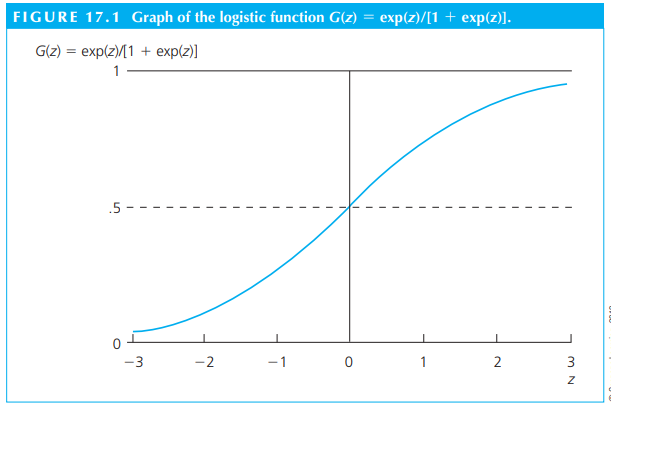

Figure 2.

The probit model uses a normal cumulative distribution:

$$F(z)=\int_{-\infty}^z \phi(v)dz$$
where $\phi(z)$ is the standard normal density function.

Here below a graphical illustration of the normal density ($f(z)$) and cumulative function $F(z)$:

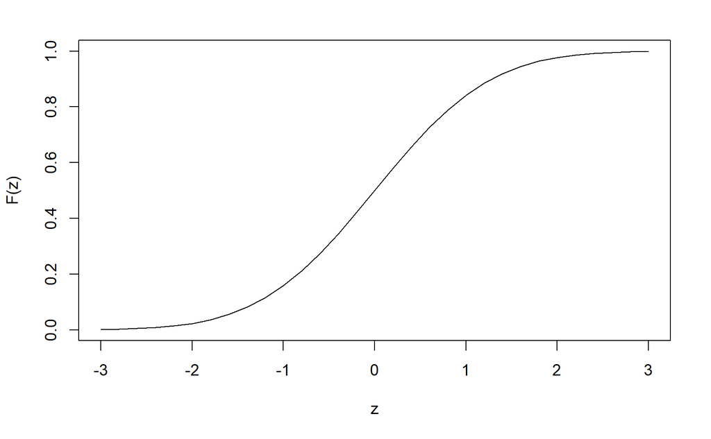

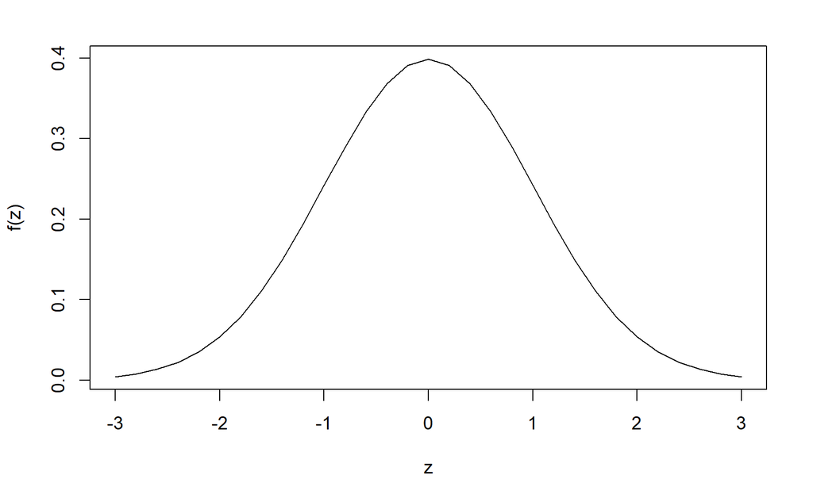

### How to find a marginal effect of a regressor in these models?

We will start from the simplest case, when we want to understand the marginal effect of a *discrete variable*. For example, let us assume that a variable $x_j$ can take discrete values, e.g., $c_m$, $m=1, 2, 3, ..., M$. Our goal is to understand the change in the probability $p(y=1|x_1, x_2, ..., x_k)$ when $x_j$ goes from $c_m$ to $c_{m+1}$.

According to what seen before:

$$\Delta p(y=1|x_1, x_2, ..., x_k, \Delta x_j) = F(\beta_0 + \beta_1 x_1 + ... + \beta_k x_j(c_{m+1}) + ... + \beta_k x_k) - F(\beta_0 + \beta_1 x_1 + ... + \beta_k x_j(c_m) + ... + \beta_k x_k)$$

To find the partial effect of a *continuous* variable $x_j$ on the response probability, we need to rely on calculus.

$$\partial p(y=1|x_1, x_2, ..., x_k) / \partial x_j = f(\beta_0 + \beta_1 x_1 + ... + \beta_k x_k) \cdot \beta_j$$

where $f(z) = \frac{\partial F(z)}{\partial z}$

In the case of probit, the function $f(z)=\phi(z)$, while in the case of logit, $f(z)=\frac{exp(z)}{[1+exp(z)]^2}$

The marginal effect is made of two components: the density function and the parameter. Since the density function is always positive, the sign of the effect depends on $\beta_j$.

Thus, for small changes in $x_j$,

$$\Delta p(y=1|x_1, ..., x_k) = f(\beta_0 + \beta_1 x_1 + ... + \beta_k x_k) \cdot \beta_j \cdot \Delta x_j$$

Compared to the linear probability model, it is harder to compute the marginal effect because the scale factor $f(\beta_0 + \beta_1 x_1 + ... + \beta_k x_k)$ depends on all $x$ regressors, which means that the estimates of the marginal effects depend on the values one plugs in the scaling factor. The same goes for the case of discrete variables, where it all depends on the values that one plugs in as for other covariates $x$ other than $x_j(c_m)$.

Hence, the question is **what values of regressors $x$ should one use?** Examples are the mean, the median values or quartiles. One method, commonly used in econometrics packages that routinely estimate probit and logit models, is to replace each explanatory variable with its sample average. In other words, the adjustment factor is:

$$f(\beta_0 + \beta_1 \bar x_1 + ... + \beta_k \bar x_k)$$

Then, the $\Delta p(y=1)$ becomes:

$$\Delta p(y=1|x_1, ..., x_k) = f(\beta_0 + \beta_1 \bar x_1 + ... + \beta_k \bar x_k) \cdot \beta_j \cdot \Delta x_j$$

The idea behind it is that, when it is multiplied by $\beta_j$, we obtain the partial effect of $x_j$ for the “average” person in the sample. Thus, when using such method, we generally obtain the **partial effect at the average (PEA)**.

There are at least two potential problems with using PEAs to summarize the partial effects of the explanatory variables.

- First, if some of the explanatory variables are discrete, the averages of them represent no one in the sample (or population, for that matter). An example is gender.
- Second, it is not clear whenever we apply a non-linear transformation to a variable whether to use the averaged transformed variable or the transformation of the averaged variable.

A different approach allows to circumvent the issue of which values to plug in for the explanatory variables. Such an alternative method relies on the averaging the individual marginal effects across individuals in the sample:

$$\Delta p(y=1|x_1, ..., x_k) = [\frac{1}{n} \cdot \Sigma_i f(\beta_0 + \beta_1 x_{i1} + ... + \beta_k x_{ik})] \cdot \beta_j \cdot \Delta x_j$$

When using such an approach, we are estimating the **average marginal effect (AME)**.

The main difference between AME and PEA is that the former is an average of a non-linear function, while the latter is a non-linear function of averaged values.

### Maximum likelihood estimation of logit and probit models

How to estimate the $\beta$ parameters in a logit or probit model? Differently from OLS, there is no explicit formula. We need to resort to maximum likelihood estimation (MLE).

Assume that we have a random sample of size n. To obtain the maximum likelihood estimator, conditional on the explanatory variables, we need the density of $y_i$ given $x_i$ We can write this as:

$$g(y|\mathbf{x_i}; \boldsymbol{\beta}) = [F(\mathbf{x_i} \boldsymbol{\beta})]^y[1-F(\mathbf{x_i}\boldsymbol{\beta})]^{1-y}~,~y=0,1$$

While function $g$, the *density of y*, may seem frighteining at first glance, it has a very simple interpretation. Our variable $y$, as we know it already, it can take values 0 and 1. When $y=0$, $g(\cdot) = 1-F(\mathbf{x_i} \boldsymbol{\beta})$, while, when $y=1$, $g(\cdot) = F(\mathbf{x_i} \boldsymbol{\beta})$. Such a function represents the probability to observe a single “success” ($y=1$) or failure ($y=0$), given all covariates and parameters. A useful hint to understand this function may be refreshing the *binomial* distribution (https://en.wikipedia.org/wiki/Binomial_distribution).

The likelihood, then, represents the probability of observing the set of “successes” (all $y=1$) and “failures” ($y=0$) in our sample, given covariates $\bf{x_i}$ and parameters $\beta$.

To do so, we first derive the **logarithm of the density g**:

$$l_i\boldsymbol(\beta)=log(g)=y_i log[F(\mathbf{x_i}\boldsymbol{\beta})] + (1-y_i) [1-F(\mathbf{x_i}\boldsymbol{\beta})]$$

to then summing it across all observations

$$L= \Sigma_i l_i(\boldsymbol{\beta})$$

By maximizing $L$ with respect to all $\beta$s, we find the probit or logit estimator, depending on whether $G(\cdot)$ is the normal or logistic cumulative density function. The maximization requires knwoledge that goes beyond this course, and it relies on numerical approximation. Any statistical software will do it for you!

### A comparison exercise of all models

We now aim to compare the estimates and performances of linear, probit and logit models. We will use the dataset MROZ from the wooldridge package. Estimates from the linear model seen in the previous sections are still valid, yet we need to correct for heteroskedasticity as we have seen in the Topic 1.

```r
lpm_rob <- coeftest(lpm, vcov = vcovHC(lpm, "HC0"))
lpm_rob
```

```
t test of coefficients:

               Estimate  Std. Error t value  Pr(>|t|)
(Intercept)  0.58551922  0.15144889  3.8661 0.0001202 ***
nwifeinc    -0.00340517  0.00151681 -2.2450 0.0250635 *
educ         0.03799530  0.00722734  5.2572 1.913e-07 ***
exper        0.03949239  0.00577907  6.8337 1.722e-11 ***
expersq     -0.00059631  0.00018899 -3.1552 0.0016683 **
age         -0.01609081  0.00238623 -6.7432 3.108e-11 ***
kidslt6     -0.26181047  0.03161391 -8.2815 5.626e-16 ***
kidsge6      0.01301223  0.01346085  0.9667 0.3340215
---
Signif. codes:  0 ‘***’ 0.001 ‘**’ 0.01 ‘*’ 0.05 ‘.’ 0.1 ‘ ’ 1
```

We then estimate both probit and logit models

```r
# probit model
probit <- glm(inlf ~ nwifeinc + educ + exper + expersq + age + kidslt6 + kidsge6, data=mroz %>% mutate(expersq=exper*exper), family = binomial(link="probit"))

# logit model
logit <- glm(inlf ~ nwifeinc + educ + exper + expersq + age + kidslt6 + kidsge6, data=mroz %>% mutate(expersq=exper*exper), family = binomial(link="logit"))
```

Let us compare the three models:

```r
stargazer(lpm_rob, probit, logit, type = "html", column.labels = c("Linear", "Probit", "Logit"), header = F, model.names = F)
```

|  | *Dependent variable:* |  |  |
| --- | --- | --- | --- |
|  |  | inlf |  |
|  | Linear | Probit | Logit |
|  | (1) | (2) | (3) |
| nwifeinc | -0.003** | -0.012** | -0.021** |
|  | (0.002) | (0.005) | (0.008) |
| educ | 0.038*** | 0.131*** | 0.221*** |
|  | (0.007) | (0.025) | (0.043) |
| exper | 0.039*** | 0.123*** | 0.206*** |
|  | (0.006) | (0.019) | (0.032) |
| expersq | -0.001*** | -0.002*** | -0.003*** |
|  | (0.0002) | (0.001) | (0.001) |
| age | -0.016*** | -0.053*** | -0.088*** |
|  | (0.002) | (0.008) | (0.015) |
| kidslt6 | -0.262*** | -0.868*** | -1.443*** |
|  | (0.032) | (0.118) | (0.204) |
| kidsge6 | 0.013 | 0.036 | 0.060 |
|  | (0.013) | (0.044) | (0.075) |
| Constant | 0.586*** | 0.270 | 0.425 |
|  | (0.151) | (0.508) | (0.860) |
| Observations |  | 753 | 753 |
| Log Likelihood |  | -401.302 | -401.765 |
| Akaike Inf. Crit. |  | 818.604 | 819.530 |
| *Note:* | p<0.1; p<0.05; p<0.01 |  |  |

Let us study the effect of $educ$. The three models depict a consistent story: education has a positive impact on the probability for a woman to enter the labor market.

However, as we have already emphasized, the magnitudes of the coefficient estimates across models are not directly comparable.

The linear probability model says that an increase of 1 year in education corresponds to an increase in probability of about 0.038 (3.8%).

To estimate the marginal effect of probit and logit model, we need to resort to either estimating the PEA or AME.

**Estimating the PEA**

For the probit model:

```r
# mean of all variables in the model
dataframe_mean <- data.frame(nwifeinc=mean(mroz$nwifeinc),exper=mean(mroz$exper),expersq=mean(mroz$expersq), age=mean(mroz$age), kidslt6=mean(mroz$kidslt6), kidsge6=mean(mroz$kidsge6), educ=mean(mroz$educ))

# retrieve linear model values
linearPredict_probit <- predict(probit, dataframe_mean, data=mroz, type="link")

# compute PEA
DpDeduc_probit <- coef(probit)[[3]]*dnorm(linearPredict_probit)
DpDeduc_probit
```

```
         1
0.05112843
```

For the logit model:

```r
# retrieve linear model values
linearPredict_logit <- predict(logit, dataframe_mean, data=mroz, type="link")

# compute PEA
DpDdtime_logit <- coef(logit)[[3]]*dlogis(linearPredict_logit)
DpDdtime_logit
```

```
         1
0.05377731
```

**Estimating the AME**

For the probit model:

```r
LinearPredict_probit <- predict(probit, type="link")
avgPred_probit <- mean(dnorm(LinearPredict_probit))
AME_probit_educ <- avgPred_probit*coef(probit)[[3]]
AME_probit_educ
```

```
[1] 0.03937009
```

```r
LinearPredict_logit <- predict(logit, type="link")
avgPred_logit <- mean(dlogis(LinearPredict_logit))
AME_logit_educ <- avgPred_logit*coef(logit)[[3]]
AME_logit_educ
```

```
[1] 0.03949652
```

### Estimating the predicted probability from a model

How to estimate the “output” of a LDV model, i.e., the probability $p(y=1|\mathbf{x})$?

Using the models estimated (Linear, probit and logit), let us estimate the probability of a woman to be in the labor market when considering the average level of all covariates.

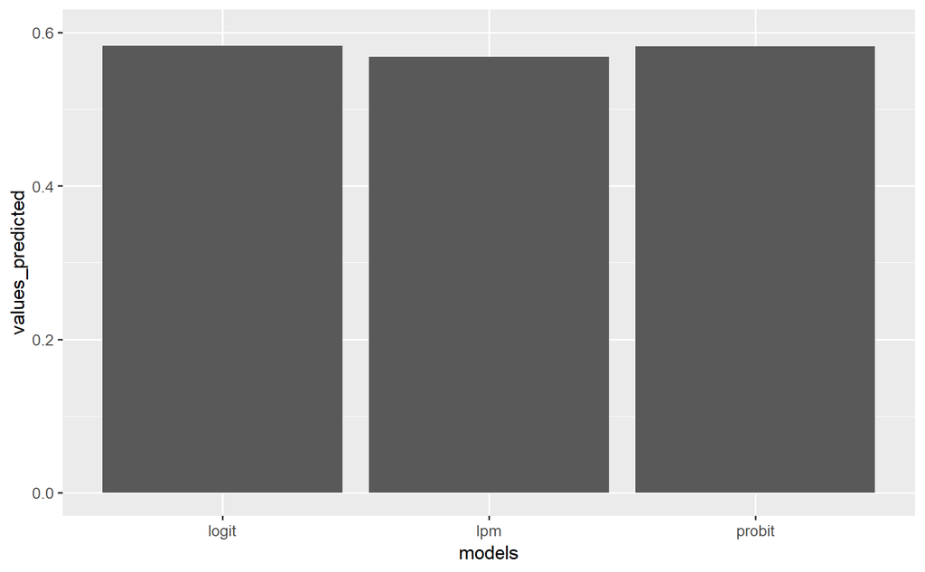

```r
# for the lpm
prob_predict_lpm <- predict(lpm, dataframe_mean, type="response")
# for the logit
prob_predict_logit <- predict(logit, dataframe_mean, type="response")
# for the probit
prob_predict_probit <- predict(probit, dataframe_mean, type="response")

predictions <- data.frame(values_predicted=c(prob_predict_lpm,prob_predict_logit,prob_predict_probit), models=c("lpm", "logit", "probit"))

ggplot(predictions, aes(y=values_predicted, x=models)) + geom_bar(stat="identity") + ylim(0, 0.6)
```

### Exercises

Use the data in LOANAPP for this exercise.

The model to estimate has to include the variable *approve* as dependent variable, which is = 1 if a mortgage loan to an individual is approved. The main covariate variable is *white*, a dummy variable equal to one if the applicant is white, zero if Hispanic or black.

1. Estimate a probit model of approve on white. Find the estimated probability of loan approval for both whites and nonwhites. How do these compare with the linear probability estimates?
2. Now, add the variables hrat, obrat, loanprc, unem, male, married, dep, sch, cosign, chist, pubrec, mortlat1, mortlat2, and vr to the probit model. Is there statistically significant evidence of discrimination against nonwhites?
3. Estimate the model from part (ii) by logit. Compare the coefficient on white to the probit estimate.
4. What is the AMA of the discrimination effects for probit and logit?

# Topic 3: Panel models

In the previous topics, we have dealt with cross-sectional data. In this topic, we will now cover the main econometrics methods that allow us to deal with data that have multiple observations for each (or some) cross-sectional observation included in the dataset.

We will cover two types of datasets in this section: **pooled cross sections** and **panel data sets** (or longitudinal data sets).

The former is obtained by sampling randomly from a large population at different points in time (usually, but not necessarily, different years). From a statistical standpoint, these data sets have an important feature: they consist of **independently** sampled observations. This was also a key aspect in our analysis of cross-sectional data: among other things, it rules out correlation in the error terms across different observations (i.e., $cov(u_{it}, u_{i, t+1})=0$).

A panel data set, while having both a cross-sectional and a time series dimension, differs in some important respects from an independently pooled cross section. To collect panel data - sometimes called longitudinal data - we follow (or attempt to follow) the same individuals, families, firms, cities, states, or whatever, across time.

Compared to previous sections, the model notation will be subject to slight modification in order to account for both dimensions in our data set.

We will deal with data of the type:

$$(y_{it}, x_{it})$$

where $i$ represents the individual dimension (firms, people, countries, etc), and $t$ indicates the time dimension (years, for example).

We will assume that there are $N$ individuals observed $T$ times.

The simplest type of models we can think about will be:

$$y_{it} = \beta_0 + \beta_1 x_{it} + u_{it}$$

The way to estimate betas in this case depends on the datasets we have and on the model assumption we make.

### 1. Pooling cross sections

One reason for using independently pooled cross sections is to increase the sample size. By pooling random samples drawn from the same population, but at different points in time, we can get more precise estimators and test statistics with more power. Pooling is helpful in this regard only insofar as the relationship between the dependent variable and at least some of the independent variables remains constant over time.

As mentioned in the introduction, using pooled cross sections raises only minor statistical complications. **Typically, to reflect the fact that the population may have different distributions in different time periods, we allow the intercept to differ across periods, usually years.** This is easily accomplished by including **dummy variables** for all but one year, where the earliest year in the sample is usually chosen as the **base year**.

A working assumption we will make throughout this section is that errors of our model are time independent The model we estimate in this case is of the type:

$$y_{it} = \beta_{Y0} + \beta_{Y1}Y1 + \beta_{Y2}Y2 + \beta_{Y3}Y3 + ... + \beta_{YT-1}YT-1 + \beta_1 x_{it} + u_{it}$$

where $\beta_{Yt}$ represents an intercept for each of the $T$ years except one (not to fall into the dummy variable trap - multicollinearity).

#### Example: Year dummies model - Women fertility over time

Sometimes, the **pattern of coefficients** on the year dummy variables is itself of interest. For example, a demographer may be interested in the following question: After controlling for education, has the pattern of fertility among women over age 35 changed between 1972 and 1984? The following example illustrates how this question is simply answered by using multiple regression analysis with year dummy variables

We will estimate a model of the type “year dummy model”. The data comes from the database $fertil1$ and it includes fertility data (number of kids) from 1972 to 1984 (collected every 2 years) of a sample of women.

We will estimate the number of kids, controlling for women’ education and age, in each year by usign dummy variables. Notice that, we will not include a dummy for year 1972 as it will be consider our “base year”.

```r
data("fertil1")

pooled <- lm(kids~educ+age+y74+y76+y78+y80+y82+y84, data=fertil1)

summary(pooled)
```

```
Call:
lm(formula = kids ~ educ + age + y74 + y76 + y78 + y80 + y82 +
    y84, data = fertil1)

Residuals:
    Min      1Q  Median      3Q     Max
-4.4218 -1.0730 -0.0818  1.0179  4.8575

Coefficients:
            Estimate Std. Error t value Pr(>|t|)
(Intercept)  3.64491    0.46487   7.841 1.04e-14 ***
educ        -0.12150    0.01826  -6.654 4.45e-11 ***
age          0.01910    0.00824   2.318  0.02064 *
y74          0.21543    0.17576   1.226  0.22057
y76         -0.18679    0.18166  -1.028  0.30408
y78         -0.13294    0.18475  -0.720  0.47193
y80         -0.09836    0.18516  -0.531  0.59538
y82         -0.45942    0.17424  -2.637  0.00849 **
y84         -0.59471    0.17743  -3.352  0.00083 ***
---
Signif. codes:  0 ‘***’ 0.001 ‘**’ 0.01 ‘*’ 0.05 ‘.’ 0.1 ‘ ’ 1

Residual standard error: 1.591 on 1120 degrees of freedom
Multiple R-squared:  0.08154,   Adjusted R-squared:  0.07498
F-statistic: 12.43 on 8 and 1120 DF,  p-value: < 2.2e-16
```

When looking at significance, however, only two year dummies are significantly different from 0, $y82$ and $y84$. When drawing conlcusions, we need to acknowledge that, despite there is a downward trend in fertility compared to 1972, the significant drop begins in 1982 onward only.

Another smart way to use year dummies is to interact them with the effect of some covariates of interest. this will allow us to capture whether the effect of some covariate changes over time.

#### Example: Year dummy interacted with covariate

We want to know whether the effect of education changes over years. This is possible via a simple interaction model. let us consider the case of two years ($T=0, 1$)

$$y_{it} = \beta_{Y0} + \beta_{Y1}Y1 + \beta_1 x_{it} + \delta_1 x_{it} \cdot Y1$$

where $\beta_1$ represents the effect of $x$ in year 0, while $\delta$ represents the effect of $x$ in year 1.

Let’s make an example. The data cps78_85 includes data on wages from a sample of americans. We want to know whether a change in education brings a change in wage. However, we want to test if the effect is different when estimated for year 1978 relative to year 1985.

$$y_{it} = \beta_{1978} + \beta_{1985}Y85 + \beta_1 education_{it} + \delta_1 education_{it} \cdot Y85$$

```r
pooled_2 <- lm(lwage~y85*educ, data=cps78_85)

summary(pooled_2)
```

```
Call:
lm(formula = lwage ~ y85 * educ, data = cps78_85)

Residuals:
     Min       1Q   Median       3Q      Max
-2.12317 -0.37158  0.01457  0.33168  1.66100

Coefficients:
            Estimate Std. Error t value Pr(>|t|)
(Intercept)  1.03045    0.09462  10.890  < 2e-16 ***
y85          0.02941    0.14155   0.208   0.8354
educ         0.05189    0.00737   7.041 3.39e-12 ***
y85:educ     0.02487    0.01082   2.297   0.0218 *
---
Signif. codes:  0 ‘***’ 0.001 ‘**’ 0.01 ‘*’ 0.05 ‘.’ 0.1 ‘ ’ 1

Residual standard error: 0.4787 on 1080 degrees of freedom
Multiple R-squared:  0.2244,    Adjusted R-squared:  0.2222
F-statistic: 104.1 on 3 and 1080 DF,  p-value: < 2.2e-16
```

Term $y85$ has the usual interpretation: it represents the difference in log(wage) in 1985 with respect to 1978. In this case its effect is not significant, hence we can say that there is no difference between years, when controlling for education.

$$1978 \rightarrow \beta_1 = 0.05$$

$$1985 \rightarrow \beta_1 + \delta_1 = 0.05189 + 0.02487$$

```r
p <- plot_model(pooled, terms = c("y74", "y76", "y78", "y80", "y82", "y84"))
```

```
Argument 'df_method' is deprecated. Please use 'ci_method' instead.
```

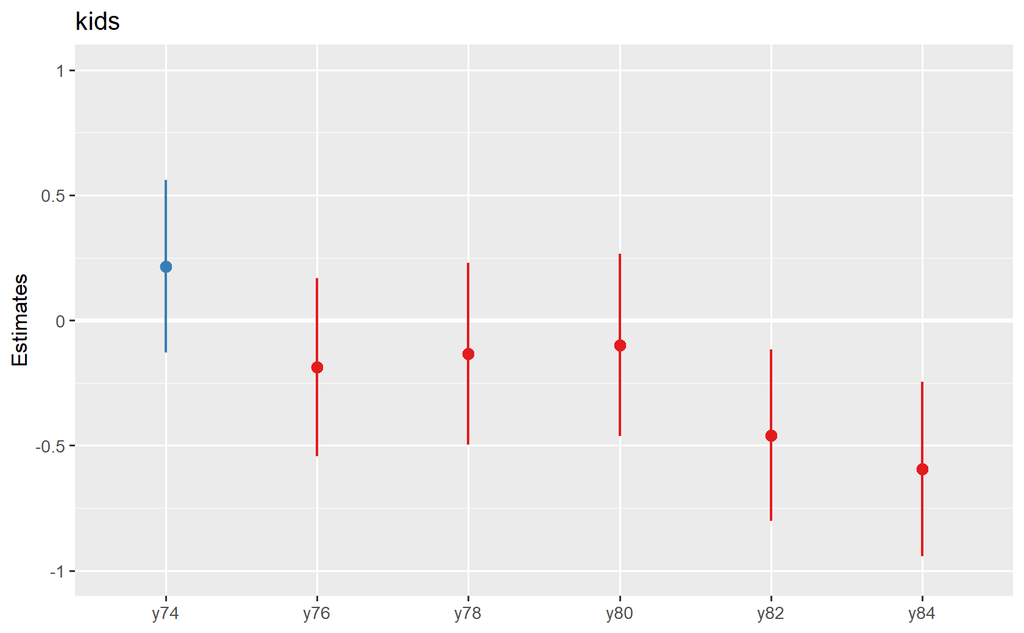

```r
p + coord_cartesian() + scale_x_discrete(limits=c("y74", "y76", "y78", "y80", "y82", "y84"))
```

#### 1.1 Policy Evaluation with Pooled cross sections

Pooled cross sections can be very useful for evaluating the impact of a certain event or policy.

For example, let us consider an event happening exogenously and affecting a given population systematically, while not affecting another. An example can be the introduction of law in a state. The goal, hence, becomes to study the change in some variable attributed to the policy or exogenous event.

Thus, our sample is usefully broken down into four groups: the control group before the change, the control group after the change, the treatment group before the change, and the treatment group after the change.

To control for systematic differences between the control and treatment groups, we need two years of data, one before the policy change and one after the change.

Call C the control group and T the treatment group, letting dT = 1 for those in the treatment group T, and zero otherwise. Then, letting $After$ denote a dummy variable for the second (post–policy change) time period, the equation of interest is:

$$y = \beta_0 + \delta_0 After + \beta_1dT + \delta_1 After \cdot dT + u$$

In this simple model, $\delta_1$ represents the difference-in-difference estimator, that is, the effect of the policy.

[figure not shown]

Figure 3.

#### Exercise

1. Effect of a Garbage Incinerator’s Location on Housing Price

In 1981, a policy introduced an incinerator near to some house in a city, hence forming two groups: houses that are near the incinerator and houses that are not. The variable $nearinc$ takes value 1 if the house is near, 0 if not.

Use the dataset $kielmc$ to estimate a diff in diff model of house price. Do not use any other control.

The y is “price”, while dummies “nearinc” and “y81” are respectively the $dT$ and $Post$ variables in the diff-in-diff model.

1. What is $\delta_1$? Is it significant?
2. What are the conclusions of this model with respect to the effect of the introdcution of the incinerator on house prices?
3. What does $\beta_1$ represent in the model?

### 2. 2-period Panel Data

We now turn into the analysis of **panel** data. We will consider data sets that contain multiple observations from the same units.

We will start with the simplest case: two periods, call these t=1 and t=2. These can be two distinct years of observation, not necessarily adjacent.

**What is the main advantage of using panel data?** A straight answer is the possibility to rule out factors that are not considered in the model, and that can bias our estimates.

As we have already seen previously, a model is a simplification of reality. It cannot include all possible factors explaining a phenomenon. Therefore, we are in most cases missing some important, unobserved factors. These factors can cause estimation problems in our OLS estimator if they are correlated with covariates that we observe. The goal is to find ways to get rid of them, or to account for their interdependence.

Put it formally:

$$\tag{fixed effects model}
y_{it} = \beta_0 + \beta_1 x_{it} + \mathbf{a_i} + u_{it}$$

where, the novel term, $\bf a_i$ are a set of variables that are relevant but are not available or we cannot observe. Notice that, these variables included in $\bf a$ are constant over times $t$. Examples are gender, city where one lives, or any other fixed characteristics of the units observed. This terms is often referred to as **fixed effects**. The model just depicted is hence called fixed effects model.

**Notes**: some authors define the fixed effect model as : $y_{it} = \alpha_i + \beta_1 x + u$, where $\alpha_i = \beta_0 + a_i$. This will come useful in later sections.

The error $u_{it}$ is often called the idiosyncratic error or time-varying error, because it represents unobserved factors that change over time and affect $y_{it}$.

Hence, the fixed effect part captures only factor that are not explained in the model and do not change over time.

**How should we estimate the parameter of interest, $\beta$s, given two years of panel data?**

**The answer depends on whether the fixed effects $a_i$ and the regressors are correlated.**

Let us assume the following model:

$$y_{it} = \beta_0 + \beta_1 x_{it} + v_{it}$$
where $v_{it}$ is a composite error including $a_i$ and $u_{it}$.

**As long as we assume $v_{it}$ to be independent (not correlated) with our regressor $x$**, we can use OLS methods.

**However, what if we cannot assume that factors $a_i$ or $u_{it}$ are independent from $x$**? Our OLS estimators would be biased as the error is correlated with our covariates. However, we can get rid of $a_i$ by difference our variables.

Assuming that we only have one regressor $x$:

$$y_{i1} = \beta_{01} + \beta_1 x_{i1} + a_i + u_{i1}$$

$$y_{i2} = \beta_{02} + \beta_1 x_{i2} + a_i + u_{i2}$$

Hence:

$$y_{i2} -y_{i1} = (\beta_{02} - \beta_{01}) + \beta_1 (x_{i2} - x_{i1}) + (u_{i2}-u_{i1})$$

The coefficient $\beta_1$ in this model called **first-difference model** is an unbiased and consistent estimator under the normal OLS assumptions.

**Limitations of the first difference model**:

1. Exploiting 2 years can allow us to overcome the effect of fixed effects. Yet it is hard to obtain multiple observations from the same sample of subjects (e.g., follow-up studies are tough!)
2. Differencing covariates $x$ can reduce their variability, which will in turn reduce the precision of OLS estimators (e.g., education over years)

```r
# 2-period panel
data(slp75_81)

slp <- slp75_81 %>% mutate(delta_sleep= slpnap81-slpnap75,
                    delta_totwork= totwrk81 - totwrk75,
                    delta_education = educ81 - educ75)

lm(delta_sleep ~ delta_totwork + delta_education, data=slp)
```

```
Call:
lm(formula = delta_sleep ~ delta_totwork + delta_education, data = slp)

Coefficients:
    (Intercept)    delta_totwork  delta_education
      -112.3578          -0.2187          -4.7539
```

### 3. Fixed Effects Estimators

#### 3.1 Within estimator

First-difference models are just a way to exploit panel data and get rid of the effect of time-invariant unobserved variables. An alternative estimator is the fixed effect one.

To derive this estimator, we need to apply a simple transformation to the *fixed effects model* seen before:

$$\tag{fixed effects model; Eq. 1}
y_{it} = \beta_0 + \beta_1 x_{it} + \mathbf{a_i} + u_{it}$$

By averaging out along the time dimension:

$$\tag{Eq. 2}
\bar y_{i} = \beta_0 + \beta_1 \bar x_{i} + \mathbf{a_i} + \bar u_{i}$$

If we subtract Eq. 2 to 1:

$$\tag{within transformation; Eq. 3}
y_{it} - \bar y_{i} = \beta_1 (x_{1,it} -\bar x_{i}) + (u_{it}-\bar u_{i})$$

we obtain the **time-demeaned data**.

The important thing about equation Eq. 3 is that the unobserved effect, $a_i$, has disappeared. This suggests that we should estimate Eq. 3 by pooled OLS.

A pooled OLS estimator that is based on the time-demeaned variables is called the **fixed effects estimator** or the **within estimator**. The latter name comes from the fact that OLS on Eq. 3 uses the time variation in y and x within each cross-sectional observation.

**Limitations of Within Estimators**:

- Regressors $x$ that are constant characteristics over time (such as gender, distance of a city relative to a river, color of eyes, etc.) disappear in the within transformation.

#### 3.2 The Dummy Variable Regression

An alternative way to approach to fixed effects is to consider the unobserved effects $a_i$ as a set of parameters to be estimated for each individual. This model with the inclusion of dummies lead to the **same estimates** of the parameter of interest $\beta_j$s.

As noted previously, the *fixed effects model* can be rewritten in the following way:

$$\tag{Dummy variable regression; Eq. 4}
y_{it} = \alpha_i + \beta_1 x_{it} + u_{it}$$

where $\alpha_i=\beta_0 + a_i$. The estimation of this model requires estimating an intercept for each individual $i$.

The way we practically estimate this model is to add a dummy variable for each unit $i$. The parameters to be estimated in such a model would then be:

- $N$ for the dummies
- k for the number of regressors $x$ we include in the model.

We would then need $N+k$ observations, at least, to make inference.

```r
# Fixed effects estimators

data("wagepan")

# dummy regression
dummy_regression <- lm(lwage~hours+as.factor(nr) - 1, data=wagepan)

# Within Estimator
new_data = wagepan %>% group_by(nr) %>% mutate(hours_demeaned =  hours - mean(hours, na.rm=T)) %>% select(nr, lwage, hours, hours_demeaned)

new_data <- with(wagepan,
                       data.frame(hours_demeaned = hours - ave(hours, nr),
                                  lwage_demeaned = lwage - ave(lwage, nr),
                                  nr=nr))
fe <- lm(lwage_demeaned~hours_demeaned-1, data=new_data)

## retrieving fixed effects
# within estimator using the plm library
library(plm)
within <- plm(lwage~hours, data=wagepan, index=c("nr", "year"), model = "within")

## with robust errors
lmtest::coeftest(within, vcovHC, type="HC0")
```

```
t test of coefficients:

         Estimate  Std. Error t value Pr(>|t|)
hours -5.5854e-07  2.5051e-05 -0.0223   0.9822
```

```r
## retrieving fixed effects
fe_intercepts <- fixef(within)
mean(fe_intercepts)
```

```
[1] 1.650371
```

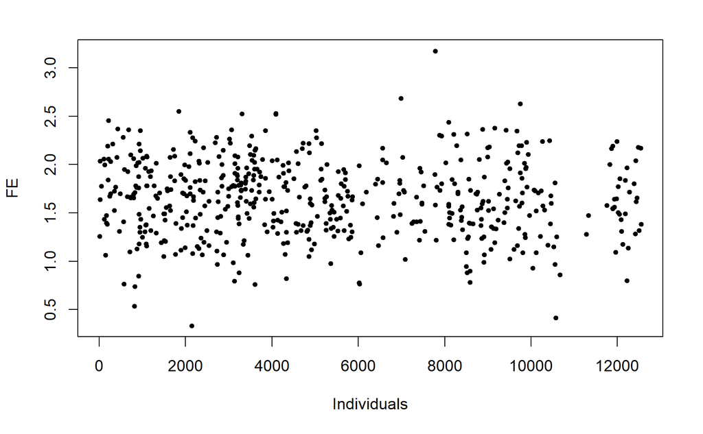

```r
labels <- as.numeric(names(fe_intercepts))
plot(fe_intercepts~labels, pch = 20, ylab = "FE", xlab = "Individuals")
```

```r
stargazer(dummy_regression, fe, within, keep = c("hours", "hours_demeaned"), model.names = F, column.labels = c("Dummy regression", "Within Estimator", "Within Estimator (lpm)"), type = "html")
```

|  | *Dependent variable:* |  |  |
| --- | --- | --- | --- |
|  | lwage | lwage_demeaned | lwage |
|  | Dummy regression | Within Estimator | Within Estimator (lpm) |
|  | (1) | (2) | (3) |
| hours | -0.00000 |  | -0.00000 |
|  | (0.00001) |  | (0.00001) |
| hours_demeaned |  | -0.00000 |  |
|  |  | (0.00001) |  |
| Observations | 4,360 | 4,360 | 4,360 |
| R<sup>2</sup> | 0.956 | 0.00000 | 0.00000 |
| Adjusted R<sup>2</sup> | 0.950 | -0.0002 | -0.143 |
| Residual Std. Error | 0.387 (df = 3814) | 0.362 (df = 4359) |  |
| F Statistic | 152.910*** (df = 546; 3814) | 0.002 (df = 1; 4359) | 0.002 (df = 1; 3814) |
| *Note:* | p<0.1; p<0.05; p<0.01 |  |  |

**Limitations**

- Many dummies to estimate. This can be a problem in terms of efficiency of the model.
- Overfitting and high $R^2$ as we fit a parameter for each individual

### 4. Random Effects Estimator

$$Cov(x_{itj}, a_i)=0$$

In this case, it is reasonable to think that we can simply use an OLS estimator, as the error is not correlated with the regressors $x$. **Shall we run single cross-section or pooled OLS?** The answer is most likely no. The reason being that we will not be able to deal with the serial correlation in our data, in particular, the fact that we do have repeated observation for each individual.

More formally, assuming the fixed effects model seen before, with a composite error $v=a_i + u_{it}$:

$$\tag{Composite Error Model; Eq. 5}
y_{it} = \beta_0 + \beta_1 x_{it} + v_{it}$$
Because the fixed effects $a_i$ are in the composite error in each time period, the $v_{it}$ are serially correlated across time.

*OLS estimators do not account for this serial correlation along time, they will hence provide biased estimates*.

A solution to this problem is then an alternative estimator, called **Generalised Least Square** or **GLS**, which allows us to account for serial correlation.

Obtaining the GLS estimator requires some math efforts, that will be skipped in this course. However, we can simply have a grasp of the data transformation, as in the case seen for fixed effect estimators:

Let us define:

$$\theta = 1 - [\frac{\sigma_u^2}{\sigma_u^2 + \sigma_a^2 T}]^{1/2}$$

where $\sigma_a^2=Var(a_i)$ and $\sigma_u^2=Var(u_{it})$.

Then, we transform the data:

$$\tag{quasi-demeaned transformation; Eq. 6}
y_{it} - \theta \bar y_{i} = \beta_0 (1-\theta) + \beta_1 (x_{1,it} -\theta \bar x_{i}) + (v_{it}-\theta \bar v_{i})$$

The way GLS estimators work is not presented for sake of simplicity. Yet, we can get a rough idea. We would need to estimate $\theta$ (i.e., $\hat \theta$) and $v_{it}$ (i.e., $\hat v_{it}$. Then, we estimate Eq. 6 using pooled OLS estimator. The estimators of the $\beta_j$ in the *quasi-demeaned model* are called **random-effects estimators**.

**Relation with Pooled OLS and Fixed effects estimators**: In the case of $\theta=1$, we obtain the Fixed Effects estimator, while in the opposite case of $\theta=0$, we obtain the Pooled OLS estimator. Hence, we can informally say that the random-effects estimator is a sort of weighted average between the two estimator classes.

**Advantages and Limitations of Random Effects:**

Advantages:

- keeping time-invariant regressors in the model

Limits:

- Assuming no correlation $Cov(a_i, u_{it})$ can be unrealistic in many cases